# Notebook

### 1. DESCARGA LIBRERÍAS

```python
import pandas as pd
import numpy as np
import seaborn as sns
import matplotlib.pyplot as plt

#normalización
from sklearn.preprocessing import MinMaxScaler

#reducción de la dimensionalidad
from sklearn.model_selection import train_test_split
from xgboost  import XGBRegressor, plot_importance
from sklearn.feature_selection import SelectFromModel, RFECV

#selección de hiperparámetros
from sklearn.model_selection import GridSearchCV, RandomizedSearchCV, StratifiedKFold

#métricas evaluación
from sklearn.metrics import (
    roc_auc_score,
    roc_curve,
    classification_report,
    confusion_matrix,
    accuracy_score,
    precision_score,
    recall_score,
    f1_score
)


#modelado
from sklearn.linear_model import LogisticRegression, LassoCV, RidgeCV
from sklearn.svm import LinearSVC
from sklearn.ensemble import RandomForestClassifier, ExtraTreesClassifier
from xgboost import XGBClassifier

import pickle

import tensorflow as tf
from tensorflow.keras.models import Sequential, load_model
from tensorflow.keras.layers import Dense, Dropout, BatchNormalization, Lambda
from tensorflow.keras.optimizers import Adam
from tensorflow.keras.callbacks import EarlyStopping, ModelCheckpoint
from tensorflow.keras.regularizers import l1, l2
```

[output not shown]

### 2. CARGA DE DATOS

```python
df_const_cerrados = pd.read_csv('df_const_cerrados_LGD.csv')
df_const_abiertos = pd.read_csv('df_const_abiertos_LGD.csv')
df_explot_cerrados = pd.read_csv('df_explot_cerrados_LGD.csv')
df_explot_abiertos = pd.read_csv('df_explot_abiertos_LGD.csv')
```

```python
df_const_cerrados.shape
```

```
(41375, 76)
```

```python
df_const_cerrados['LGD'].value_counts()
```

```
LGD
0.0    24215
1.0    17160
Name: count, dtype: int64
```

```python
target = df_const_cerrados['LGD']
features= df_const_cerrados.drop('LGD', axis=1)
```

**IMPORTANTE**: Dado que el conjunto de explotación sólo cuenta con un histórico de 1 año y dicho plazo es muy corto para considerar cómo realmente cerrados los procesos recuperatorios que la entidad ya ha clasificado como "Charged Off" (se pueden seguir obteniendo flujos tras dicha clasificación), se va a considerar todo el conjunto de explotación (cerrados + abiertos) como conjunto a predecir.  
Pero antes de eso, necesitamos estimar el 2% de procesos abiertos, clasificados como "default" del conjunto de construcción y una vez obtengamos la estimación total de los cerrados más los abiertos del conjunto de construcción, estimaremos los procesos recuperatorios del conjunto de explotación.

```python
df_explot = pd.concat([df_explot_cerrados, df_explot_abiertos], axis=0)
```

### 3. SEPARACIÓN TRAIN Y TEST

```python
X_train, X_test, y_train, y_test = train_test_split(
    features,
    target,
    test_size=0.2,
    stratify=target,
    random_state=42
)
```

```python
X_train.shape, X_test.shape
```

```
((33100, 75), (8275, 75))
```

```python
y_train.shape, y_test.shape
```

```
((33100,), (8275,))
```

Se trata de un dataset bastante menos desbalanceado que el dataset de PD, por lo que no será necesario balancearlo artificialmente para su entrenamiento. Además observamos que al usar el hiperparámetro `stratify` al separar entre entrenamiento y validación, las proporciones se mantienen exactamente igual entre ambas muestras.

```python
y_train.value_counts()/len(y_train)
```

```
LGD
0.0    0.585257
1.0    0.414743
Name: count, dtype: float64
```

```python
y_test.value_counts()/len(y_test)
```

```
LGD
0.0    0.585257
1.0    0.414743
Name: count, dtype: float64
```

### 4. REDUCCIÓN DIMENSIONALIDAD

4.1 MÉTODO WRAPPER: RECURSIVE FEATURE ELIMINATION

**RECURSIVE FEATURE ELIMINATION**

```python
# model = LogisticRegression(solver="liblinear")
# rfecv = RFECV(estimator=model, step=1, cv=StratifiedKFold(2), scoring='roc_auc')
```

```python
#Entrenamos el modelo

# rfecv.fit(X_train, y_train)
```

```python
#Ver cuáles han sido las mejores variables

# rfecv.support_
```

```python
#Ver el score del modelo

# rfecv.k_score_
```

4.2 MÉTODO EMBEDDED

**LASSO (L1)**

[output not shown]

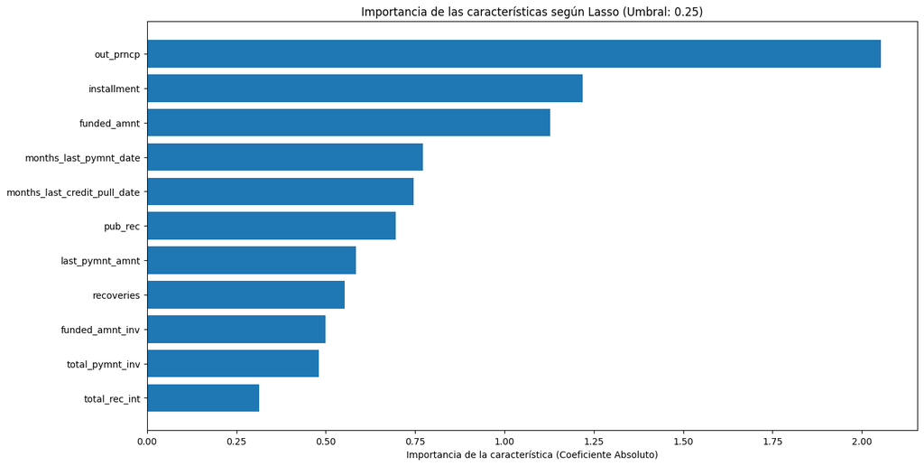

```python
# Modelo Lasso con validación cruzada para encontrar el mejor alpha
lasso = LassoCV(cv=5, random_state=42).fit(X_train, y_train)

# Selección de variables con SelectFromModel
model = SelectFromModel(lasso, prefit=True)

# Obtenemos las importancias de las características (coeficientes absolutos)
feature_importances = np.abs(lasso.coef_)

# Nombres de las variables
feature_names = X_train.columns.tolist()

# Definimos el umbral para seleccionar características
threshold = 0.25

# Filtramos características por encima del umbral
selected_indices = np.where(feature_importances > threshold)[0]
selected_feature_names = [feature_names[i] for i in selected_indices]
selected_importances = feature_importances[selected_indices]


# Ordenamos las características seleccionadas por importancia
sorted_indices = np.argsort(selected_importances)[::-1]
sorted_importances = selected_importances[sorted_indices]
sorted_variable_names = [selected_feature_names[i] for i in sorted_indices]

# Graficamos las importancias de las características seleccionadas
plt.figure(figsize=(15, 8))
plt.barh(sorted_variable_names, sorted_importances, align='center')
plt.xlabel('Importancia de la característica (Coeficiente Absoluto)')
plt.title(f'Importancia de las características según Lasso (Umbral: {threshold})')
plt.gca().invert_yaxis()  # Invertimos el eje Y para que la más importante esté arriba
plt.show()
```

```python
#vemos cuáles son esas variables
sorted_variable_names
```

```
['out_prncp',
 'installment',
 'funded_amnt',
 'months_last_pymnt_date',
 'months_last_credit_pull_date',
 'pub_rec',
 'last_pymnt_amnt',
 'recoveries',
 'funded_amnt_inv',
 'total_pymnt_inv',
 'total_rec_int']
```

```python
#Filtramos nuestros datasets con las variables más importantes seleccionadas por este modelo
X_train_lasso = X_train[sorted_variable_names]
X_test_lasso = X_test[sorted_variable_names]
features_const_abiertos_lasso = df_const_abiertos[sorted_variable_names]
features_explot_lasso = df_explot[sorted_variable_names]
```

**RANDOM FOREST**

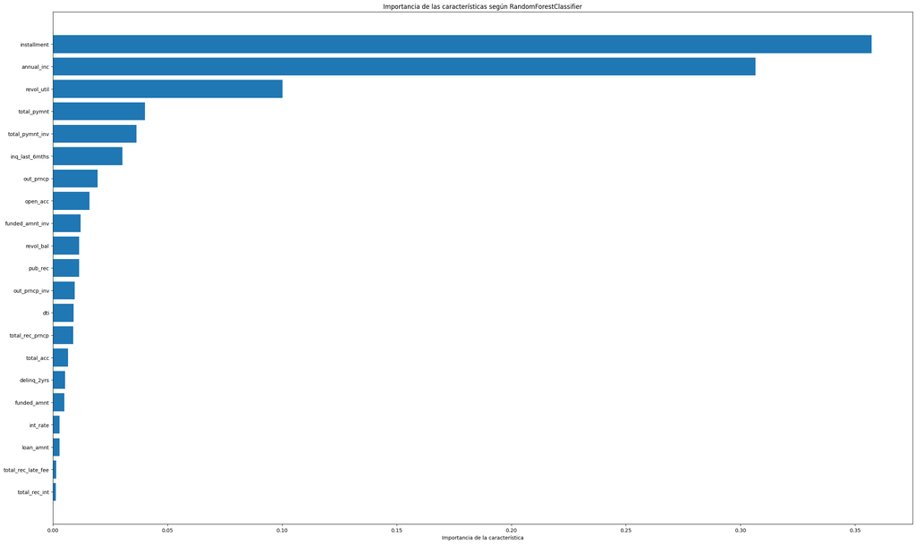

```python
random_forest = RandomForestClassifier (max_depth = 5).fit(X_train, y_train)

# Selección de las variables más importantes
model = SelectFromModel (random_forest, prefit=True) #prefit=True indica si el modelo fue entrenado antes de pasarlo a SelectFromModel, En este caso, el modelo no será reentrenado

# Obtenemos las importancias de las características
feature_importances = random_forest.feature_importances_

# Definir los nombres de las variables y un umbral
feature_names = X_train.columns.tolist()
threshold = 0.001

#filtrar las características por encima de ese umbral
selected_indices = np.where(feature_importances > threshold)[0]
selected_feature_names = [feature_names[i] for i in selected_indices]
selected_importances = feature_importances[selected_indices]


# Ordenamos las características por importancia
sorted_indices = np.argsort(selected_importances)[::-1]
sorted_importances = selected_importances[sorted_indices]
sorted_variable_names = [feature_names[i] for i in sorted_indices]

# Graficamos las importancias
plt.figure(figsize=(30, 18))
plt.barh(sorted_variable_names, sorted_importances, align='center')
plt.xlabel('Importancia de la característica')
plt.title('Importancia de las características según RandomForestClassifier')
plt.gca().invert_yaxis()  # Invertimos el eje Y para que la más importante esté arriba
plt.show()
```

```python
#Aplicamos las variables seleccionadas a los conjuntos de entrenamiento, test y validación
X_train_rf = X_train[sorted_variable_names]
X_test_rf = X_test[sorted_variable_names]
features_const_abiertos_rf = df_const_abiertos[sorted_variable_names]
features_explot_rf = df_explot[sorted_variable_names]
```

```python
sorted_variable_names
```

```
['installment',
 'annual_inc',
 'revol_util',
 'total_pymnt',
 'total_pymnt_inv',
 'inq_last_6mths',
 'out_prncp',
 'open_acc',
 'funded_amnt_inv',
 'revol_bal',
 'pub_rec',
 'out_prncp_inv',
 'dti',
 'total_rec_prncp',
 'total_acc',
 'delinq_2yrs',
 'funded_amnt',
 'int_rate',
 'loan_amnt',
 'total_rec_late_fee',
 'total_rec_int']
```

```python
X_test_rf.shape, features_const_abiertos_rf.shape, features_explot_rf.shape
```

```
((8275, 21), (780, 21), (2588, 21))
```

**XGBOOST**

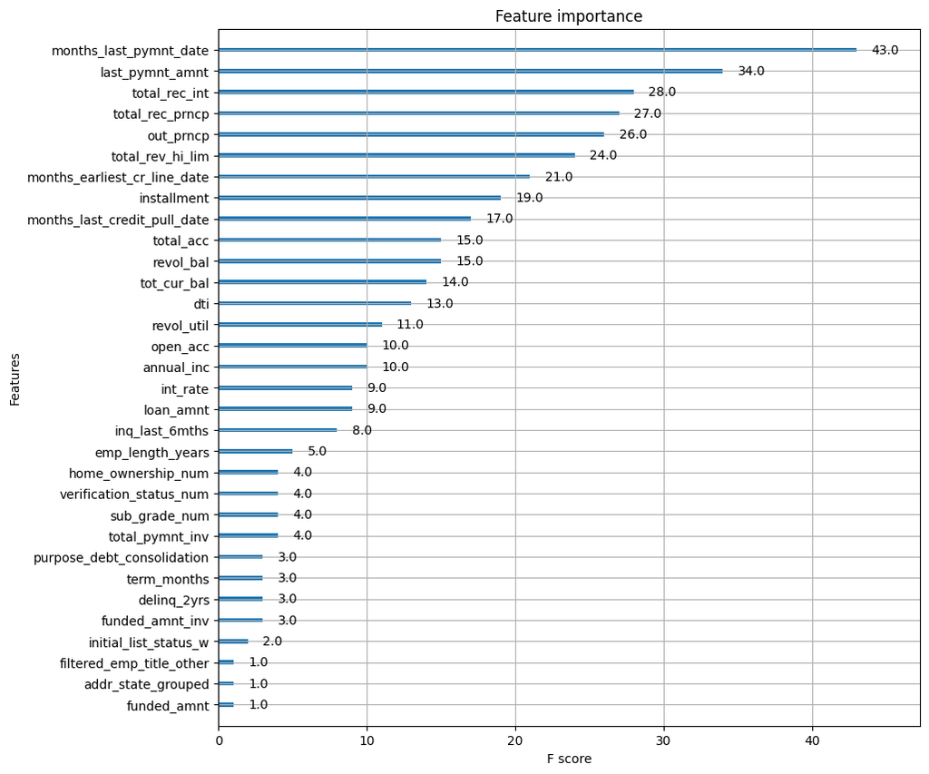

```python
xgb = XGBClassifier(max_depth=3, min_child_weight=5, gamma=0.3) #scale_pos_weight=scale_pos_weight)

xgb_model = xgb.fit(X_train, y_train)

# Crear la figura
fig, ax = plt.subplots(figsize=(10, 10))

# Mostrar la importancia de las características
plot_importance(xgb, ax=ax)

# Mostrar la gráfica
plt.show()
```

```python
# Extraer todas las variables ordenadas del gráfico
all_features = [text.get_text() for text in ax.get_yticklabels()]

# Extraer los valores del F score directamente desde el modelo
importance_dict = xgb.get_booster().get_score(importance_type='weight')

# Crear un DataFrame con las variables y su F score
importance_df = pd.DataFrame({
    'Feature': list(importance_dict.keys()),
    'F_score': list(importance_dict.values())
})

# Filtrar las variables con un F score por encima de un umbral
threshold = 10
important_features = importance_df[importance_df['F_score'] > threshold]

# Si quieres quedarte con solo los nombres de las variables:
important_features = important_features['Feature'].tolist()
important_features
```

```
['installment',
 'dti',
 'revol_bal',
 'revol_util',
 'total_acc',
 'out_prncp',
 'total_rec_prncp',
 'total_rec_int',
 'last_pymnt_amnt',
 'tot_cur_bal',
 'total_rev_hi_lim',
 'months_earliest_cr_line_date',
 'months_last_pymnt_date',
 'months_last_credit_pull_date']
```

```python
# Reducimos el número de variables a las que más información aportan al modelo, tanto para el conjunto train como para el conjunto test y explotación

X_train_xgb = X_train[important_features]
X_test_xgb = X_test[important_features]
features_const_abiertos_xgb = df_const_abiertos[important_features]
features_explot_xgb = df_explot[important_features]
```

### 5. CREAR FUNCIÓN CON MÉTRICAS DE EVALUACIÓN

```python
def evaluate_model(model, X_train, y_train, X_test, y_test):

    # Predicciones y probabilidades para el conjunto de entrenamiento
    y_train_pred = model.predict(X_train)
    y_train_proba = model.predict_proba(X_train)[:, 1]

    # Predicciones y probabilidades para el conjunto de prueba
    y_test_pred = model.predict(X_test)
    y_test_proba = model.predict_proba(X_test)[:, 1]

    # ROC AUC para el conjunto de entrenamiento
    train_roc_auc = roc_auc_score(y_train, y_train_proba)
    # ROC AUC para el conjunto de prueba
    test_roc_auc = roc_auc_score(y_test, y_test_proba)

    print("\n--- Entrenamiento ---")
    print("ROC AUC:", train_roc_auc)
    print("Confusion Matrix:")
    print(confusion_matrix(y_train, y_train_pred))
    print("\nClassification Report:")
    print(classification_report(y_train, y_train_pred))

    print("\n--- Prueba ---")
    print("ROC AUC:", test_roc_auc)
    print("Confusion Matrix:")
    print(confusion_matrix(y_test, y_test_pred))
    print("\nClassification Report:")
    print(classification_report(y_test, y_test_pred))

    # Curva ROC
    fpr_train, tpr_train, _ = roc_curve(y_train, y_train_proba)
    fpr_test, tpr_test, _ = roc_curve(y_test, y_test_proba)

    plt.figure(figsize=(10, 6))
    plt.plot(fpr_train, tpr_train, label="Train ROC (AUC = {:.2f})".format(train_roc_auc))
    plt.plot(fpr_test, tpr_test, label="Test ROC (AUC = {:.2f})".format(test_roc_auc))
    plt.plot([0, 1], [0, 1], "k--", label="Random Guess")
    plt.xlabel("False Positive Rate")
    plt.ylabel("True Positive Rate")
    plt.title("ROC Curve")
    plt.legend()
    plt.show()
```

### 6. AJUSTE DE HIPERPARÁMETROS Y MODELADO

**REGRESIÓN LOGÍSTICA**

```python
model_lr = LogisticRegression(
    penalty='l2', #(Ridge): reduce el tamaño de los coeficientes, pero sin hacerlos 0.
    C=0.01, #Controla la penalización de los coeficientes (inversa de la regularización).
    solver='lbfgs', #por defecto en L2, recomendado para datasets medianos a grandes.
    max_iter=100, # max_iter asegura convergencia
    class_weight = 'balanced',#'balanced': ajusta automáticamente los pesos de cada clase.
    random_state=42

)


model_lr.fit(X_train_lasso, y_train)
```

```
LogisticRegression(C=0.01, class_weight='balanced', random_state=42)
```

```python
# Hacer predicciones
y_train_pred_lr = model_lr.predict(X_train_lasso)
y_test_pred_lr = model_lr.predict(X_test_lasso)
```

```python
# Calcular probabilidades para ROC AUC
y_train_proba_lr = model_lr.predict_proba(X_train_lasso)[:, 1]
y_test_proba_lr = model_lr.predict_proba(X_test_lasso)[:, 1]
```

```
--- Entrenamiento ---
ROC AUC: 0.9968514111155551
Confusion Matrix:
[[19341    31]
 [ 1977 11751]]

Classification Report:
              precision    recall  f1-score   support

         0.0       0.91      1.00      0.95     19372
         1.0       1.00      0.86      0.92     13728

    accuracy                           0.94     33100
   macro avg       0.95      0.93      0.94     33100
weighted avg       0.94      0.94      0.94     33100


--- Prueba ---
ROC AUC: 0.9968640606416778
Confusion Matrix:
[[4836    7]
 [ 489 2943]]

Classification Report:
              precision    recall  f1-score   support

         0.0       0.91      1.00      0.95      4843
         1.0       1.00      0.86      0.92      3432

    accuracy                           0.94      8275
   macro avg       0.95      0.93      0.94      8275
weighted avg       0.95      0.94      0.94      8275
```

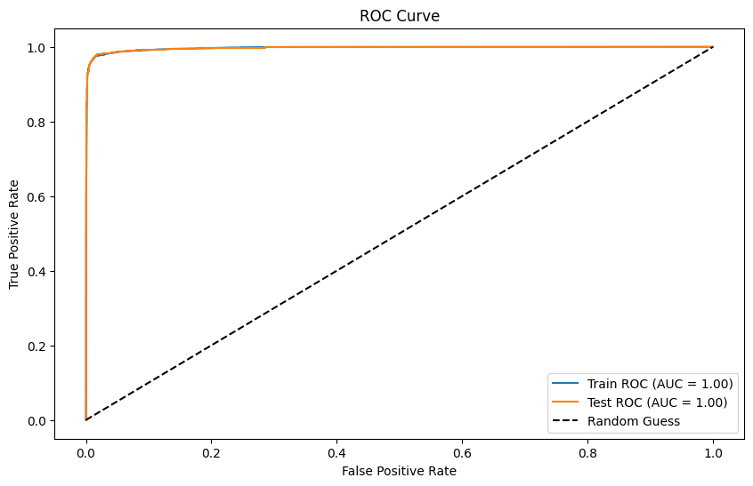

```python
evaluate_model(model_lr, X_train_lasso, y_train, X_test_lasso, y_test)
```

**RANDOM FOREST**

```python
# Crear y entrenar el modelo de Random Forest

model_rf = RandomForestClassifier(
    n_estimators=100, #Número de árboles en el bosque.
    max_depth=5, #profundidad máxima de los árboles
    min_samples_split=5,  #Número mínimo de muestras requeridas para dividir un nodo (cuanto más alto menos sobreajuste)
    min_samples_leaf=3, #Número mínimo de muestras requeridas en una hoja (cuanto más alto menos sobreajuste)
    max_features='sqrt', #Número máximo de features consideradas en cada división.
    bootstrap=True,  #Si True, usa muestreo con reemplazo, lo que ayuda a la generalización
    random_state=32,
    n_jobs=-1,
    class_weight = "balanced"
)

model_rf.fit(X_train_rf, y_train)
```

```
RandomForestClassifier(class_weight='balanced', max_depth=5, min_samples_leaf=3,
                       min_samples_split=5, n_jobs=-1, random_state=32)
```

```python
# Hacer predicciones
y_train_pred_rf = model_rf.predict(X_train_rf)
y_test_pred_rf = model_rf.predict(X_test_rf)
```

```python
# Calcular probabilidades para ROC AUC
y_train_proba_rf = model_rf.predict_proba(X_train_rf)[:, 1]
y_test_proba_rf = model_rf.predict_proba(X_test_rf)[:, 1]
```

```
--- Entrenamiento ---
ROC AUC: 1.0
Confusion Matrix:
[[19372     0]
 [    0 13728]]

Classification Report:
              precision    recall  f1-score   support

         0.0       1.00      1.00      1.00     19372
         1.0       1.00      1.00      1.00     13728

    accuracy                           1.00     33100
   macro avg       1.00      1.00      1.00     33100
weighted avg       1.00      1.00      1.00     33100


--- Prueba ---
ROC AUC: 1.0
Confusion Matrix:
[[4843    0]
 [   0 3432]]

Classification Report:
              precision    recall  f1-score   support

         0.0       1.00      1.00      1.00      4843
         1.0       1.00      1.00      1.00      3432

    accuracy                           1.00      8275
   macro avg       1.00      1.00      1.00      8275
weighted avg       1.00      1.00      1.00      8275
```

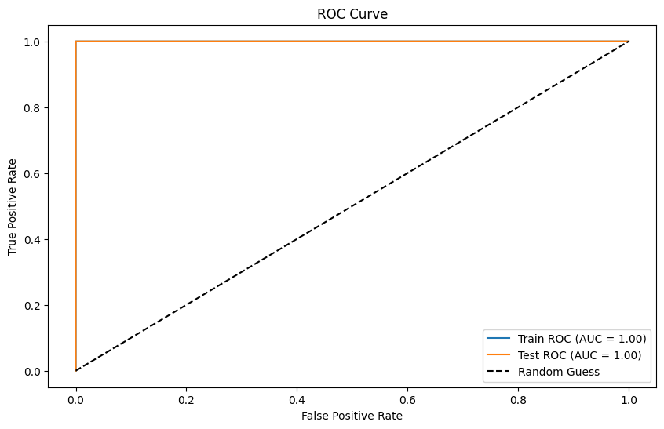

```python
evaluate_model(model_rf, X_train_rf, y_train, X_test_rf, y_test)
```

**XGBOOST**

```python
model_xgb = XGBClassifier(
    max_depth=4, #Define la profundidad máxima de los árboles.
    min_child_weight=6, #Define la cantidad mínima de observaciones necesarias en un nodo hijo antes de dividirse.
    gamma=0.2, #Define la reducción mínima en la pérdida para hacer una nueva división en un nodo.
    reg_lambda=3, #Controla la penalización de los coeficientes grandes (similar a Ridge Regression).
    reg_alpha=2, #Induce sparsity (puede ayudar si hay muchas variables irrelevantes).
    colsample_bytree=0.7, #Porcentaje de variables usadas en cada árbol.
    learning_rate=0.05, #Reduce el impacto de cada árbol en la predicción final.
    n_estimators=500, #Número de árboles a entrenar.
    random_state=42,
    class_weight = "balanced",
    n_jobs=-1
)

model_xgb.fit(X_train_xgb, y_train)
```

```
XGBClassifier(base_score=None, booster=None, callbacks=None,
              class_weight='balanced', colsample_bylevel=None,
              colsample_bynode=None, colsample_bytree=0.7, device=None,
              early_stopping_rounds=None, enable_categorical=False,
              eval_metric=None, feature_types=None, gamma=0.2, grow_policy=None,
              importance_type=None, interaction_constraints=None,
              learning_rate=0.05, max_bin=None, max_cat_threshold=None,
              max_cat_to_onehot=None, max_delta_step=None, max_depth=4,
              max_leaves=None, min_child_weight=6, missing=nan,
              monotone_constraints=None, multi_strategy=None, n_estimators=500,
              n_jobs=-1, num_parallel_tree=None, ...)
```

```python
# Hacer predicciones
y_train_pred_xgb = model_xgb.predict(X_train_xgb)
y_test_pred_xgb = model_xgb.predict(X_test_xgb)
```

```python
# Calcular probabilidades para ROC AUC
y_train_proba_xgb = model_xgb.predict_proba(X_train_xgb)[:, 1]
y_test_proba_xgb = model_xgb.predict_proba(X_test_xgb)[:, 1]
```

```
--- Entrenamiento ---
ROC AUC: 0.999951432437753
Confusion Matrix:
[[19371     1]
 [   38 13690]]

Classification Report:
              precision    recall  f1-score   support

         0.0       1.00      1.00      1.00     19372
         1.0       1.00      1.00      1.00     13728

    accuracy                           1.00     33100
   macro avg       1.00      1.00      1.00     33100
weighted avg       1.00      1.00      1.00     33100


--- Prueba ---
ROC AUC: 0.9997488144039868
Confusion Matrix:
[[4843    0]
 [  13 3419]]

Classification Report:
              precision    recall  f1-score   support

         0.0       1.00      1.00      1.00      4843
         1.0       1.00      1.00      1.00      3432

    accuracy                           1.00      8275
   macro avg       1.00      1.00      1.00      8275
weighted avg       1.00      1.00      1.00      8275
```

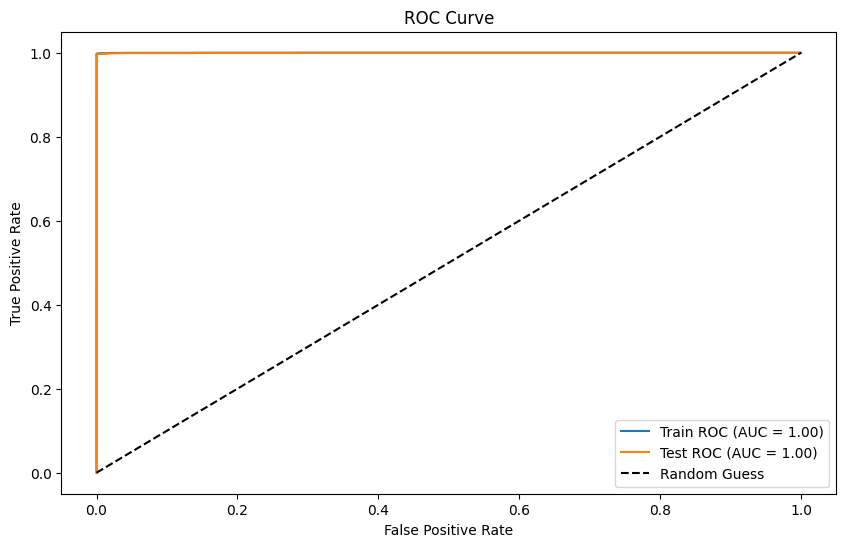

```python
evaluate_model(model_xgb, X_train_xgb, y_train, X_test_xgb, y_test)
```

**RED NEURONAL**

En primer lugar, puesto que no hemos llevado a cabo ninguna reducción de la dimensionalidad, nos vamos a quedar sólo con las variables que se encuentren tanto en entrenamiento/test y en validación.

```python
# Encontrar columnas comunes entre X_train y df_explot
common_columns = list(set(X_train.columns) & set(df_explot.columns) & set(df_const_abiertos.columns))

# Filtrar ambos DataFrames para conservar solo las columnas en común
X_train_nn = X_train[common_columns]
X_test_nn = X_test[common_columns]
df_const_abiertos_nn = df_const_abiertos[common_columns]
df_explot_nn = df_explot[common_columns]
```

```python
X_train_nn.shape, df_explot_nn.shape, df_const_abiertos_nn.shape
```

```
((33100, 61), (2588, 61), (780, 61))
```

```python
# Definir el coeficiente de regularización L2
lambda_l1 = 0.05

model = Sequential([
    Dense(128, activation='relu', input_shape=(X_train_nn.shape[1],), kernel_regularizer=l1(lambda_l1)),
    BatchNormalization(),
    Dropout(0.2),

    Dense(64, activation='relu', kernel_regularizer=l1(lambda_l1)),
    BatchNormalization(),
    Dropout(0.2),

    Dense(32, activation='relu', kernel_regularizer=l1(lambda_l1)),
    Dropout(0.1),

    Dense(1, activation='sigmoid')  # Salida binaria
])
```

```
2025-03-10 09:24:10.641210: E external/local_xla/xla/stream_executor/cuda/cuda_driver.cc:152] failed call to cuInit: INTERNAL: CUDA error: Failed call to cuInit: CUDA_ERROR_NO_DEVICE: no CUDA-capable device is detected
```

```python
# Compilar el modelo
model.compile(
    optimizer=Adam(learning_rate=0.0001, decay=1e-6),  #una tasa de apredije menor a 0.0001, la red da unos saltos demasiado grandes, no llegando en ocasiones a coverger en resultados óptimos
    loss='binary_crossentropy',
    metrics=['AUC']
)
```

```python
# Callback para parada temprana
early_stopping = EarlyStopping(
    monitor='val_loss',  # Métrica a monitorear
    patience=3,          # Número de épocas sin mejora antes de detener el entrenamiento
    restore_best_weights=True  # Restaurar los pesos del mejor modelo
)
```

```python
# Callback para guardar el modelo después de cada época
checkpoint_callback = ModelCheckpoint(
    filepath='clasificador_nn_LGD.keras',  # Nombre del archivo donde se guarda
    monitor='val_loss',               # Métrica a monitorear
    save_best_only=True,              # Guardar solo el mejor modelo
    mode='min',                       # Minimizar la métrica (val_loss en este caso)
    verbose=1                         # Mostrar mensajes de guardado
)
```

```python
# Entrenar el modelo
history = model.fit(
    X_train_nn, y_train,
    validation_data=(X_test_nn, y_test),
    epochs=25,              # Número máximo de épocas (parada temprana detendrá antes si es necesario)
    batch_size=128,
    callbacks=[early_stopping, checkpoint_callback],  # Añadir los callbacks
    verbose=1
)
```

```
254/259 ━━━━━━━━━━━━━━━━━━━━ 0s 3ms/step - AUC: 0.4996 - loss: 79.6996
Epoch 1: val_loss improved from inf to 63.76324, saving model to clasificador_nn_LGD.keras
259/259 ━━━━━━━━━━━━━━━━━━━━ 4s 5ms/step - AUC: 0.5002 - loss: 79.5754 - val_AUC: 0.6883 - val_loss: 63.7632
254/259 ━━━━━━━━━━━━━━━━━━━━ 0s 3ms/step - AUC: 0.5993 - loss: 59.1834
Epoch 2: val_loss improved from 63.76324 to 45.65545, saving model to clasificador_nn_LGD.keras
259/259 ━━━━━━━━━━━━━━━━━━━━ 1s 4ms/step - AUC: 0.5999 - loss: 59.0776 - val_AUC: 0.7886 - val_loss: 45.6554
253/259 ━━━━━━━━━━━━━━━━━━━━ 0s 3ms/step - AUC: 0.7054 - loss: 41.8079
Epoch 3: val_loss improved from 45.65545 to 30.60682, saving model to clasificador_nn_LGD.keras
259/259 ━━━━━━━━━━━━━━━━━━━━ 1s 4ms/step - AUC: 0.7061 - loss: 41.7051 - val_AUC: 0.8635 - val_loss: 30.6068
245/259 ━━━━━━━━━━━━━━━━━━━━ 0s 3ms/step - AUC: 0.8181 - loss: 27.5811
Epoch 4: val_loss improved from 30.60682 to 18.67357, saving model to clasificador_nn_LGD.keras
259/259 ━━━━━━━━━━━━━━━━━━━━ 1s 4ms/step - AUC: 0.8194 - loss: 27.4051 - val_AUC: 0.9254 - val_loss: 18.6736
253/259 ━━━━━━━━━━━━━━━━━━━━ 0s 3ms/step - AUC: 0.9020 - loss: 16.2780
Epoch 5: val_loss improved from 18.67357 to 9.82329, saving model to clasificador_nn_LGD.keras
259/259 ━━━━━━━━━━━━━━━━━━━━ 1s 4ms/step - AUC: 0.9025 - loss: 16.2168 - val_AUC: 0.9723 - val_loss: 9.8233
255/259 ━━━━━━━━━━━━━━━━━━━━ 0s 3ms/step - AUC: 0.9665 - loss: 8.1523
Epoch 6: val_loss improved from 9.82329 to 4.18913, saving model to clasificador_nn_LGD.keras
259/259 ━━━━━━━━━━━━━━━━━━━━ 1s 4ms/step - AUC: 0.9667 - loss: 8.1241 - val_AUC: 0.9966 - val_loss: 4.1891
253/259 ━━━━━━━━━━━━━━━━━━━━ 0s 3ms/step - AUC: 0.9915 - loss: 3.3455
Epoch 7: val_loss improved from 4.18913 to 1.76591, saving model to clasificador_nn_LGD.keras
259/259 ━━━━━━━━━━━━━━━━━━━━ 1s 4ms/step - AUC: 0.9915 - loss: 3.3285 - val_AUC: 0.9989 - val_loss: 1.7659
253/259 ━━━━━━━━━━━━━━━━━━━━ 0s 3ms/step - AUC: 0.9952 - loss: 1.5650
Epoch 8: val_loss improved from 1.76591 to 1.02835, saving model to clasificador_nn_LGD.keras
259/259 ━━━━━━━━━━━━━━━━━━━━ 1s 4ms/step - AUC: 0.9951 - loss: 1.5600 - val_AUC: 0.9992 - val_loss: 1.0283
253/259 ━━━━━━━━━━━━━━━━━━━━ 0s 3ms/step - AUC: 0.9941 - loss: 0.9443
Epoch 9: val_loss improved from 1.02835 to 0.65260, saving model to clasificador_nn_LGD.keras
259/259 ━━━━━━━━━━━━━━━━━━━━ 1s 4ms/step - AUC: 0.9941 - loss: 0.9417 - val_AUC: 0.9993 - val_loss: 0.6526
253/259 ━━━━━━━━━━━━━━━━━━━━ 0s 3ms/step - AUC: 0.9938 - loss: 0.6480
Epoch 10: val_loss improved from 0.65260 to 0.54185, saving model to clasificador_nn_LGD.keras
259/259 ━━━━━━━━━━━━━━━━━━━━ 1s 4ms/step - AUC: 0.9938 - loss: 0.6472 - val_AUC: 0.9994 - val_loss: 0.5419
253/259 ━━━━━━━━━━━━━━━━━━━━ 0s 3ms/step - AUC: 0.9934 - loss: 0.5661
Epoch 11: val_loss improved from 0.54185 to 0.49187, saving model to clasificador_nn_LGD.keras
259/259 ━━━━━━━━━━━━━━━━━━━━ 1s 4ms/step - AUC: 0.9934 - loss: 0.5658 - val_AUC: 0.9995 - val_loss: 0.4919
253/259 ━━━━━━━━━━━━━━━━━━━━ 0s 3ms/step - AUC: 0.9940 - loss: 0.5217
Epoch 12: val_loss improved from 0.49187 to 0.44744, saving model to clasificador_nn_LGD.keras
259/259 ━━━━━━━━━━━━━━━━━━━━ 1s 4ms/step - AUC: 0.9940 - loss: 0.5215 - val_AUC: 0.9995 - val_loss: 0.4474
254/259 ━━━━━━━━━━━━━━━━━━━━ 0s 3ms/step - AUC: 0.9942 - loss: 0.4896
Epoch 13: val_loss improved from 0.44744 to 0.41971, saving model to clasificador_nn_LGD.keras
259/259 ━━━━━━━━━━━━━━━━━━━━ 1s 4ms/step - AUC: 0.9943 - loss: 0.4895 - val_AUC: 0.9995 - val_loss: 0.4197
255/259 ━━━━━━━━━━━━━━━━━━━━ 0s 3ms/step - AUC: 0.9952 - loss: 0.4674
```

[output cut: 20 more lines]

```
253/259 ━━━━━━━━━━━━━━━━━━━━ 0s 3ms/step - AUC: 0.9957 - loss: 0.3787
Epoch 21: val_loss improved from 0.32409 to 0.31075, saving model to clasificador_nn_LGD.keras
259/259 ━━━━━━━━━━━━━━━━━━━━ 1s 4ms/step - AUC: 0.9957 - loss: 0.3787 - val_AUC: 0.9996 - val_loss: 0.3108
253/259 ━━━━━━━━━━━━━━━━━━━━ 0s 3ms/step - AUC: 0.9959 - loss: 0.3688
Epoch 22: val_loss did not improve from 0.31075
259/259 ━━━━━━━━━━━━━━━━━━━━ 1s 4ms/step - AUC: 0.9959 - loss: 0.3688 - val_AUC: 0.9995 - val_loss: 0.3125
252/259 ━━━━━━━━━━━━━━━━━━━━ 0s 3ms/step - AUC: 0.9961 - loss: 0.3616
Epoch 23: val_loss improved from 0.31075 to 0.29650, saving model to clasificador_nn_LGD.keras
259/259 ━━━━━━━━━━━━━━━━━━━━ 1s 4ms/step - AUC: 0.9961 - loss: 0.3615 - val_AUC: 0.9997 - val_loss: 0.2965
252/259 ━━━━━━━━━━━━━━━━━━━━ 0s 3ms/step - AUC: 0.9964 - loss: 0.3536
Epoch 24: val_loss improved from 0.29650 to 0.28634, saving model to clasificador_nn_LGD.keras
259/259 ━━━━━━━━━━━━━━━━━━━━ 1s 4ms/step - AUC: 0.9964 - loss: 0.3536 - val_AUC: 0.9996 - val_loss: 0.2863
253/259 ━━━━━━━━━━━━━━━━━━━━ 0s 3ms/step - AUC: 0.9954 - loss: 0.3512
Epoch 25: val_loss did not improve from 0.28634
259/259 ━━━━━━━━━━━━━━━━━━━━ 1s 3ms/step - AUC: 0.9954 - loss: 0.3511 - val_AUC: 0.9996 - val_loss: 0.2874
```

```python
# Extraer los datos del entrenamiento
history_dict = history.history
```

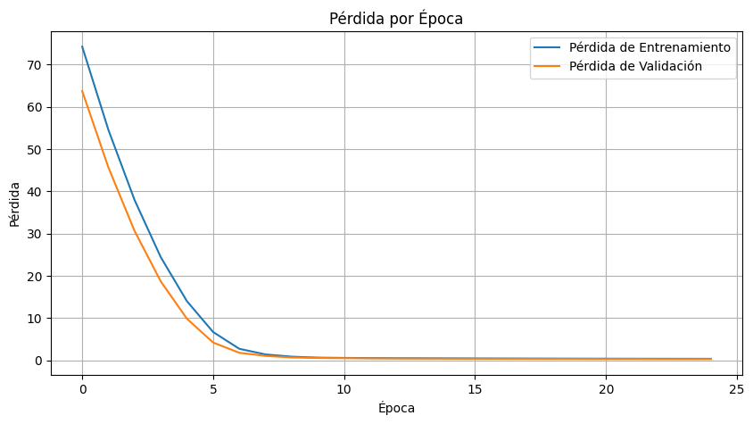

```python
# Gráficos de pérdida (loss)
plt.figure(figsize=(10, 5))
plt.plot(history_dict['loss'], label='Pérdida de Entrenamiento')
plt.plot(history_dict['val_loss'], label='Pérdida de Validación')
plt.title('Pérdida por Época')
plt.xlabel('Época')
plt.ylabel('Pérdida')
plt.legend()
plt.grid()
plt.show()
```

```python
# Gráficos de ROC AUC, si está disponible
if 'mse' in history_dict:
    plt.figure(figsize=(10, 5))
    plt.plot(history_dict['mse'], label='MSE de Entrenamiento')
    plt.plot(history_dict['val_mse'], label='MSE de Validación')
    plt.title('MSE por Época')
    plt.xlabel('Época')
    plt.ylabel('MSE')
    plt.legend()
    plt.grid()
    plt.show()
```

```python
# Evaluación con .evaluate
loss, roc_auc = model.evaluate(X_test_nn, y_test)

# Predicciones manuales
y_pred_proba = model.predict(X_test_nn)
roc_auc_manual = roc_auc_score(y_test, y_pred_proba)

print(f"ROC AUC (.evaluate): {roc_auc:.4f}")
print(f"ROC AUC (manual): {roc_auc_manual:.4f}")
```

```
259/259 ━━━━━━━━━━━━━━━━━━━━ 0s 1ms/step - AUC: 0.9999 - loss: 0.2839
259/259 ━━━━━━━━━━━━━━━━━━━━ 0s 1ms/step
ROC AUC (.evaluate): 0.9996
ROC AUC (manual): 0.9996
```

### 6. GUARDAMOS EL MODELO

```python
with open('clasificador_lr_LGD', 'wb') as f:
    pickle.dump(model_lr, f)
```

```python
with open('clasificador_rf_LGD', 'wb') as f:
    pickle.dump(model_rf, f)
```

```python
with open('clasificador_xgb_LGD', 'wb') as f:
    pickle.dump(model_xgb, f)
```

```python
#PARA LA RED NEURONAL no hace falta guardar el modelo porque ya hemos incluido un callback en el código de la red neuronal que guarda automáticamente el modelo

# model.save('clasificador_nn_LGD.keras')
```

### 7. PREDECIR SOBRE EL CONJUNTO DE PROCESOS RECUPERATORIOS DE CONSTRUCCIÓN ABIERTOS

Una vez tenemos los modelos entrenados y probados sobre los procesos recuperatorios cerrados del conjunto de construcción, tenemos que estimar los procesos recuperatorios abiertos de ese mismo conjunto, para así lograr obtener la muestra completa de cerrados del conjunto de construcción, y con dicha muestra poder estimar el conjunto de explotación.  
Dado los scores tan elevados obtenidos en todos los modelos, podemos seleccionar cualquiera para predecir.

**REGRESIÓN LOGÍSTICA**

```python
#Cargar el modelo
with open('clasificador_lr_LGD', 'rb') as f:
    loaded_model_lr = pickle.load(f)
```

Variables más importantes seleccionadas por el modelo Lasso

```python
X_train_lasso.columns
```

```
Index(['out_prncp', 'installment', 'funded_amnt', 'months_last_pymnt_date',
       'months_last_credit_pull_date', 'pub_rec', 'last_pymnt_amnt',
       'recoveries', 'funded_amnt_inv', 'total_pymnt_inv', 'total_rec_int'],
      dtype='object')
```

```python
#Predecimos sobre los procesos abiertos del conjunto de construcción
y_pred_lr = loaded_model_lr.predict(df_const_abiertos[X_train_lasso.columns])
```

```python
y_pred_lr
```

```
array([0., 0., 0., 0., 0., 0., 0., 0., 0., 1., 1., 0., 1., 0., 1., 0., 0.,
       0., 0., 1., 1., 1., 0., 0., 1., 0., 0., 1., 0., 0., 1., 0., 0., 0.,
       0., 1., 1., 1., 0., 0., 0., 1., 0., 0., 1., 0., 1., 1., 1., 1., 1.,
       1., 1., 0., 1., 0., 0., 0., 0., 1., 1., 0., 0., 0., 1., 0., 0., 1.,
       1., 0., 0., 1., 1., 1., 1., 0., 0., 0., 1., 0., 0., 0., 1., 1., 0.,
       1., 0., 0., 0., 1., 1., 0., 1., 1., 0., 0., 0., 1., 0., 0., 0., 1.,
       1., 1., 0., 0., 1., 0., 0., 0., 0., 0., 0., 0., 0., 0., 0., 0., 1.,
       0., 0., 0., 0., 0., 0., 0., 0., 1., 1., 0., 0., 1., 1., 0., 0., 0.,
       0., 0., 1., 0., 0., 0., 0., 0., 0., 0., 0., 0., 0., 0., 0., 1., 0.,
       1., 0., 1., 0., 0., 1., 0., 0., 1., 0., 1., 0., 0., 0., 0., 0., 0.,
       0., 0., 1., 0., 0., 0., 0., 0., 0., 0., 0., 0., 0., 0., 0., 1., 0.,
       0., 0., 0., 0., 1., 0., 0., 0., 0., 0., 0., 0., 0., 0., 0., 0., 0.,
       1., 0., 1., 0., 0., 0., 0., 0., 0., 0., 0., 1., 1., 0., 1., 0., 0.,
       0., 1., 0., 1., 1., 1., 1., 1., 1., 0., 1., 1., 1., 1., 1., 1., 1.,
       0., 1., 1., 0., 1., 1., 1., 1., 0., 1., 1., 0., 0., 0., 1., 1., 1.,
       1., 1., 1., 1., 1., 1., 1., 0., 0., 1., 1., 0., 1., 1., 0., 1., 0.,
       1., 1., 1., 0., 1., 1., 0., 1., 0., 1., 0., 1., 1., 0., 1., 1., 1.,
       1., 1., 1., 1., 1., 0., 1., 1., 0., 1., 1., 0., 0., 1., 1., 1., 1.,
       1., 1., 1., 1., 1., 1., 1., 1., 1., 1., 0., 1., 1., 1., 0., 1., 1.,
       1., 1., 1., 1., 1., 1., 0., 1., 1., 1., 1., 1., 1., 0., 1., 1., 0.,
       1., 1., 1., 1., 1., 1., 1., 1., 1., 1., 1., 0., 1., 1., 1., 0., 1.,
       1., 1., 1., 1., 1., 1., 1., 1., 1., 0., 0., 1., 1., 1., 1., 1., 1.,
       1., 0., 1., 1., 1., 1., 1., 1., 1., 1., 1., 1., 1., 1., 1., 1., 1.,
       1., 0., 1., 0., 0., 0., 0., 0., 1., 1., 0., 1., 1., 0., 1., 1., 1.,
       0., 1., 1., 1., 1., 1., 1., 0., 1., 1., 1., 1., 1., 1., 1., 1., 1.,
       1., 1., 1., 1., 0., 1., 0., 0., 1., 0., 1., 1., 1., 1., 1., 0., 0.,
       1., 1., 0., 1., 1., 1., 1., 1., 1., 1., 1., 1., 1., 1., 1., 1., 0.,
       1., 1., 1., 1., 1., 1., 0., 0., 1., 1., 1., 0., 1., 1., 0., 1., 0.,
       1., 1., 0., 1., 1., 1., 1., 0., 1., 1., 1., 1., 1., 1., 1., 1., 0.,
       1., 1., 1., 1., 1., 1., 1., 0., 1., 0., 0., 1., 0., 1., 1., 0., 1.,
       0., 0., 1., 1., 1., 1., 1., 1., 0., 0., 1., 1., 1., 1., 1., 1., 0.,
       0., 1., 1., 0., 1., 1., 0., 1., 0., 1., 1., 1., 1., 1., 1., 0., 1.,
       1., 0., 1., 0., 1., 1., 1., 1., 0., 1., 1., 0., 1., 0., 1., 1., 1.,
       0., 1., 1., 1., 0., 1., 0., 1., 1., 1., 0., 0., 1., 1., 1., 0., 0.,
       1., 0., 0., 0., 1., 0., 1., 1., 1., 0., 1., 1., 1., 1., 0., 1., 1.,
       1., 1., 0., 1., 0., 1., 1., 1., 1., 1., 1., 0., 0., 1., 0., 0., 1.,
       0., 1., 0., 0., 0., 0., 1., 1., 1., 0., 0., 1., 1., 0., 0., 0., 0.,
       0., 0., 1., 0., 1., 1., 1., 1., 1., 1., 0., 1., 0., 1., 0., 1., 0.,
       1., 1., 1., 1., 1., 1., 1., 0., 0., 1., 1., 1., 1., 0., 1., 1., 1.,
       1., 1., 1., 0., 1., 0., 1., 1., 1., 0., 1., 0., 1., 1., 0., 1., 0.,
       0., 1., 1., 0., 1., 0., 1., 1., 0., 1., 1., 0., 1., 0., 1., 1., 1.,
       1., 1., 0., 1., 1., 1., 0., 1., 1., 1., 1., 1., 0., 1., 0., 1., 0.,
       1., 1., 0., 1., 1., 1., 0., 0., 0., 0., 1., 1., 1., 0., 0., 1., 0.,
       1., 1., 1., 1., 1., 1., 1., 1., 1., 1., 1., 1., 1., 1., 0., 0., 0.,
       0., 1., 0., 1., 0., 1., 0., 1., 0., 1., 0., 1., 0., 1., 0., 1., 1.,
       1., 0., 0., 1., 1., 1., 0., 1., 0., 1., 1., 1., 1., 1., 0.])
```

Incluimos la predicción con el resto de variables explicativas seleccionadas por el modelo Lasso.

```python
df_const_abiertos['LGD'] = y_pred_lr
```

Por lo que ya tenemos el conjunto de procesos recuperatorios de la muestra de construcción completa, tanto los procesos cerrados como los procesos abiertos.

La LGD media de la cartera de los procesos cerrados era de un 41,5% aproximadamente, cifra que tiene sentido si la comparamos con la LGD facilitada por la CRR para préstamos minoristas sin garantía.

```python
df_const_cerrados['LGD'].mean()
```

```
0.4147432024169184
```

La LGD media **estimada** para los procesos recuperatorios abiertos de la muestra de construcción es bastante más elevada, que la de los procesos cerrados. ¿A qué puede deberse?

1. Recuperaciones en curso: En los procesos abiertos, es posible que aún no se haya logrado una recuperación significativa, lo que hace que el modelo los estime con una LGD más alta.
2. Efecto de sesgo temporal: En muchos casos, los préstamos con mayores probabilidades de recuperación se cierran antes, mientras que los más difíciles de recuperar permanecen abiertos, elevando la LGD media de este grupo.
3. Estructura del modelo: al entrenar el modelo con datos históricos, puede estar capturando patrones que indican que los casos más recientes (aún abiertos) tienen una probabilidad más alta de no recuperación total.

```python
df_const_abiertos['LGD'].mean()
```

```
0.5948717948717949
```

```python
df_const = pd.concat([df_const_cerrados, df_const_abiertos], axis=0)
```

```python
# Calcular el total de filas de df_const
total_filas = len(df_const)

# Calcular el porcentaje de df_const_cerrados y df_const_abiertos
porcentaje_cerrados = (len(df_const_cerrados) / total_filas) * 100
porcentaje_abiertos = (len(df_const_abiertos) / total_filas) * 100

# Mostrar los resultados
print(f"Porcentaje de df_const_cerrados: {porcentaje_cerrados:.2f}%")
print(f"Porcentaje de df_const_abiertos: {porcentaje_abiertos:.2f}%")
```

```
Porcentaje de df_const_cerrados: 98.15%
Porcentaje de df_const_abiertos: 1.85%
```

```python
df_const['LGD'].mean()
```

```
0.4180761475507057
```

Al concatenar ambos dataset debemos tener cuidado porque no poseen el mismo número de columnas y si concatenamos, el dataset con menor número de columnas se rellenará con NaNs.

```python
df_const_cerrados.shape, df_const_abiertos.shape
```

```
((41375, 76), (780, 73))
```

Al tratarse de variables identificadas como NO claves para los algoritmos anteriormente desarrollados, podemos proceder a eliminarlas para no tener probelmas posteriormente al modelizar.

```python
nulls_const = df_const.isna().mean()*100
```

```python
nulls_const[(nulls_const>0)]
```

```
pymnt_plan_y                1.850314
purpose_educational         1.850314
purpose_renewable_energy    1.850314
dtype: float64
```

```python
df_const_nulos = df_const[df_const.isna().any(axis=1)]
df_const_nulos[['pymnt_plan_y', 'purpose_educational', 'purpose_renewable_energy']]
```

|  | pymnt_plan_y | purpose_educational | purpose_renewable_energy |
| --- | --- | --- | --- |
| 0 | NaN | NaN | NaN |
| 1 | NaN | NaN | NaN |
| 2 | NaN | NaN | NaN |
| 3 | NaN | NaN | NaN |
| 4 | NaN | NaN | NaN |
| ... | ... | ... | ... |
| 775 | NaN | NaN | NaN |
| 776 | NaN | NaN | NaN |
| 777 | NaN | NaN | NaN |
| 778 | NaN | NaN | NaN |
| 779 | NaN | NaN | NaN |

780 rows × 3 columns

```python
#Eliminamos dichas variables
df_const.drop(['pymnt_plan_y', 'purpose_educational', 'purpose_renewable_energy'], axis=1, inplace=True)
```

**RANDOM FOREST**

```python
#Cargar el modelo
with open('clasificador_rf_LGD', 'rb') as f:
    loaded_model_rf = pickle.load(f)
```

```python
X_train_rf.columns
```

```
Index(['installment', 'annual_inc', 'revol_util', 'total_pymnt',
       'total_pymnt_inv', 'inq_last_6mths', 'out_prncp', 'open_acc',
       'funded_amnt_inv', 'revol_bal', 'pub_rec', 'out_prncp_inv', 'dti',
       'total_rec_prncp', 'total_acc', 'delinq_2yrs', 'funded_amnt',
       'int_rate', 'loan_amnt', 'total_rec_late_fee', 'total_rec_int'],
      dtype='object')
```

```python
#Predecimos sobre los procesos abiertos del conjunto de construcción
y_pred_rf = loaded_model_rf.predict(df_const_abiertos[X_train_rf.columns])
```

```python
y_pred_rf
```

```
array([0., 0., 0., 0., 0., 0., 0., 0., 0., 1., 1., 0., 1., 0., 1., 0., 0.,
       0., 0., 1., 1., 1., 0., 0., 1., 0., 0., 1., 0., 0., 1., 0., 0., 0.,
       0., 1., 1., 1., 0., 0., 0., 1., 0., 0., 1., 0., 1., 1., 1., 1., 1.,
       1., 1., 0., 1., 0., 0., 1., 0., 1., 1., 0., 0., 0., 1., 0., 1., 1.,
       1., 0., 0., 1., 1., 1., 1., 0., 0., 0., 1., 0., 0., 1., 1., 1., 0.,
       1., 0., 0., 0., 1., 1., 0., 1., 1., 1., 0., 0., 1., 0., 0., 0., 1.,
       1., 1., 0., 0., 1., 0., 0., 0., 0., 0., 0., 1., 0., 0., 0., 0., 1.,
       1., 0., 1., 0., 0., 0., 0., 0., 1., 1., 0., 1., 1., 1., 1., 0., 0.,
       1., 0., 1., 0., 0., 0., 0., 0., 0., 0., 0., 0., 1., 0., 0., 1., 0.,
       1., 1., 1., 0., 0., 1., 0., 0., 1., 1., 1., 0., 0., 1., 1., 1., 0.,
       0., 0., 1., 1., 1., 0., 0., 0., 1., 0., 0., 0., 0., 0., 0., 1., 0.,
       0., 0., 0., 0., 1., 0., 0., 0., 0., 0., 0., 0., 0., 0., 0., 0., 0.,
       1., 0., 1., 0., 0., 0., 0., 0., 0., 0., 0., 1., 1., 1., 1., 1., 0.,
       0., 1., 0., 1., 1., 1., 1., 1., 1., 0., 1., 1., 1., 1., 1., 1., 1.,
       0., 1., 1., 0., 1., 1., 1., 1., 0., 1., 1., 0., 0., 0., 1., 1., 1.,
       1., 1., 1., 1., 1., 1., 1., 0., 0., 1., 1., 0., 1., 1., 0., 1., 0.,
       1., 1., 1., 0., 1., 1., 0., 1., 0., 1., 0., 1., 1., 0., 1., 1., 1.,
       1., 1., 1., 1., 1., 0., 1., 1., 0., 1., 1., 0., 0., 1., 1., 1., 1.,
       1., 1., 1., 1., 1., 1., 1., 1., 1., 1., 0., 1., 1., 1., 0., 1., 1.,
       1., 1., 1., 1., 1., 1., 0., 1., 1., 1., 1., 1., 1., 0., 1., 1., 1.,
       1., 1., 1., 1., 1., 1., 1., 1., 1., 1., 1., 1., 1., 1., 1., 0., 1.,
       1., 1., 1., 1., 1., 1., 1., 1., 1., 0., 0., 1., 1., 1., 1., 1., 1.,
       1., 0., 1., 1., 1., 1., 1., 1., 1., 1., 1., 1., 1., 1., 1., 1., 1.,
       1., 0., 1., 0., 0., 0., 0., 0., 1., 1., 0., 1., 1., 0., 1., 1., 1.,
       0., 1., 1., 1., 1., 1., 1., 0., 1., 1., 1., 1., 1., 1., 1., 1., 1.,
       1., 1., 1., 1., 0., 1., 0., 0., 1., 0., 1., 1., 1., 1., 1., 0., 0.,
       1., 1., 0., 1., 1., 1., 1., 1., 1., 1., 1., 1., 1., 1., 1., 1., 0.,
       1., 1., 1., 1., 1., 1., 0., 1., 1., 1., 1., 0., 1., 1., 0., 0., 0.,
       1., 1., 0., 1., 1., 1., 1., 0., 1., 1., 1., 1., 1., 1., 1., 1., 0.,
       1., 1., 1., 1., 1., 1., 1., 0., 1., 0., 0., 1., 0., 1., 1., 0., 1.,
       0., 0., 1., 1., 1., 1., 1., 1., 0., 0., 1., 1., 1., 1., 1., 1., 0.,
       0., 1., 1., 0., 1., 1., 0., 1., 0., 1., 1., 1., 1., 1., 1., 0., 1.,
       1., 0., 1., 0., 1., 1., 1., 1., 0., 1., 1., 0., 1., 0., 1., 1., 1.,
       0., 1., 1., 1., 0., 1., 0., 1., 1., 1., 0., 0., 1., 1., 1., 0., 0.,
       1., 1., 0., 0., 1., 0., 1., 1., 1., 0., 1., 1., 1., 1., 0., 1., 1.,
       1., 1., 0., 1., 0., 1., 1., 1., 1., 1., 1., 0., 0., 1., 0., 0., 1.,
       1., 1., 0., 0., 0., 0., 1., 1., 1., 0., 0., 1., 1., 0., 0., 1., 0.,
       0., 0., 1., 0., 1., 1., 1., 1., 1., 1., 0., 1., 0., 1., 0., 1., 0.,
       1., 1., 1., 1., 1., 1., 1., 0., 0., 1., 1., 1., 1., 0., 1., 1., 1.,
       1., 1., 1., 0., 1., 0., 1., 1., 1., 0., 1., 1., 1., 1., 1., 1., 0.,
       0., 1., 1., 0., 1., 0., 1., 1., 0., 1., 1., 0., 1., 0., 1., 1., 1.,
       1., 1., 0., 1., 1., 1., 0., 1., 1., 1., 1., 1., 0., 1., 0., 1., 0.,
       1., 1., 0., 1., 1., 1., 0., 0., 0., 0., 1., 1., 1., 0., 0., 1., 0.,
       1., 1., 1., 1., 1., 1., 1., 1., 1., 1., 1., 1., 1., 1., 0., 1., 0.,
       0., 1., 0., 1., 0., 1., 0., 1., 0., 1., 0., 1., 0., 1., 0., 1., 1.,
       1., 0., 0., 1., 1., 1., 0., 1., 0., 1., 1., 1., 1., 1., 0.])
```

```python
df_const_abiertos['LGD'] = y_pred_lr
```

```python
df_const_abiertos['LGD'].mean()
```

```
0.5948717948717949
```

**XGBOOST**

```python
#Cargar el modelo
with open('clasificador_xgb_LGD', 'rb') as f:
    loaded_model_xgb = pickle.load(f)
```

```python
X_train_xgb.columns
```

```
Index(['installment', 'dti', 'revol_bal', 'revol_util', 'total_acc',
       'out_prncp', 'total_rec_prncp', 'total_rec_int', 'last_pymnt_amnt',
       'tot_cur_bal', 'total_rev_hi_lim', 'months_earliest_cr_line_date',
       'months_last_pymnt_date', 'months_last_credit_pull_date'],
      dtype='object')
```

```python
#Predecimos sobre los procesos abiertos del conjunto de construcción
y_pred_xgb = loaded_model_xgb.predict(df_const_abiertos[X_train_xgb.columns])
```

```python
df_const_abiertos['LGD'] = y_pred_xgb
```

La LGD media, estimada con el algoritmo XGBoost, de los procesos procesos abiertos para la muestra de construcción es ligeramente superior a la estimada con los 2 modelos anteriores.

```python
df_const_abiertos['LGD'].mean()
```

```
0.632051282051282
```

**RED NEURONAL**

```python
#cargar el modelo
modelo_cargado_nn = load_model("clasificador_nn_LGD.keras")
```

```python
X_train_nn.columns
```

```
Index(['total_rec_late_fee', 'purpose_major_purchase', 'tot_cur_bal',
       'filtered_emp_title_driver', 'filtered_emp_title_technology',
       'total_pymnt_inv', 'funded_amnt_inv', 'total_rec_int',
       'total_rec_prncp', 'purpose_credit_card', 'total_rev_hi_lim',
       'filtered_emp_title_finance', 'last_pymnt_amnt', 'revol_bal',
       'filtered_emp_title_senior', 'installment', 'recoveries',
       'out_prncp_inv', 'addr_state_grouped', 'filtered_emp_title_operations',
       'months_last_pymnt_date', 'term_months', 'annual_inc',
       'emp_length_years', 'months_last_credit_pull_date',
       'purpose_debt_consolidation', 'inq_last_6mths', 'grade_num',
       'verification_status_num', 'total_acc', 'filtered_emp_title_security',
       'purpose_medical', 'initial_list_status_w', 'delinq_2yrs',
       'collections_12_mths_ex_med', 'dti', 'out_prncp',
       'collection_recovery_fee', 'int_rate', 'sub_grade_num', 'purpose_house',
       'funded_amnt', 'tot_coll_amt', 'pub_rec', 'acc_now_delinq',
       'revol_util', 'open_acc', 'purpose_small_business',
       'filtered_emp_title_specialist', 'purpose_other', 'zip_code_grouped',
       'filtered_emp_title_healthcare', 'purpose_moving', 'loan_amnt',
       'total_pymnt', 'months_earliest_cr_line_date', 'purpose_vacation',
       'filtered_emp_title_management', 'purpose_home_improvement',
       'filtered_emp_title_other', 'home_ownership_num'],
      dtype='object')
```

```python
df_const_abiertos_nn[X_train_nn.columns]
```

|  | total_rec_late_fee | purpose_major_purchase | tot_cur_bal | filtered_emp_title_driver | filtered_emp_title_technology | total_pymnt_inv | funded_amnt_inv | total_rec_int | total_rec_prncp | purpose_credit_card | ... | filtered_emp_title_healthcare | purpose_moving | loan_amnt | total_pymnt | months_earliest_cr_line_date | purpose_vacation | filtered_emp_title_management | purpose_home_improvement | filtered_emp_title_other | home_ownership_num |
| --- | --- | --- | --- | --- | --- | --- | --- | --- | --- | --- | --- | --- | --- | --- | --- | --- | --- | --- | --- | --- | --- |
| 0 | 0.0 | False | 0.071892 | False | False | 0.019334 | 0.117647 | 0.018671 | 0.016786 | False | ... | False | False | 0.117647 | 0.019334 | 0.649742 | False | False | False | True | 0.0 |
| 1 | 0.0 | False | 0.071892 | False | False | 0.175966 | 0.147059 | 0.120426 | 0.171429 | False | ... | False | False | 0.147059 | 0.175966 | 0.581756 | False | False | False | True | 0.0 |
| 2 | 0.0 | True | 0.071892 | False | False | 0.521535 | 0.499265 | 0.342833 | 0.514286 | False | ... | False | False | 0.500000 | 0.522260 | 0.640275 | False | False | False | False | 1.0 |
| 3 | 0.0 | False | 0.071892 | False | False | 0.441213 | 0.481618 | 0.125364 | 0.497143 | False | ... | False | False | 0.482353 | 0.441848 | 0.701377 | False | False | True | True | 1.0 |
| 4 | 0.0 | False | 0.071892 | False | False | 0.414216 | 0.492647 | 0.008576 | 0.514286 | True | ... | False | False | 0.500000 | 0.420050 | 0.661790 | False | False | False | True | 1.0 |
| ... | ... | ... | ... | ... | ... | ... | ... | ... | ... | ... | ... | ... | ... | ... | ... | ... | ... | ... | ... | ... | ... |
| 775 | 0.0 | False | 0.010006 | False | False | 0.189756 | 0.261765 | 0.157136 | 0.175179 | False | ... | False | False | 0.262500 | 0.190236 | 0.650602 | False | False | False | True | 0.0 |
| 776 | 0.0 | False | 0.033375 | False | False | 0.170505 | 0.323529 | 0.287968 | 0.101581 | True | ... | False | False | 0.323529 | 0.170505 | 0.802065 | False | False | False | False | 0.5 |
| 777 | 0.0 | False | 0.183760 | False | False | 0.348307 | 0.558824 | 0.168157 | 0.365777 | False | ... | False | False | 0.558824 | 0.348307 | 0.644578 | False | False | False | True | 1.0 |
| 778 | 0.0 | False | 0.046944 | False | False | 0.227236 | 0.322059 | 0.182553 | 0.212360 | False | ... | False | False | 0.323529 | 0.228187 | 0.748709 | False | False | False | False | 0.0 |
| 779 | 0.0 | False | 0.003752 | False | False | 0.037869 | 0.008824 | 0.025251 | 0.037143 | False | ... | False | False | 0.008824 | 0.037869 | 0.827883 | False | False | False | False | 0.0 |

780 rows × 61 columns

```python
y_pred_proba_nn = modelo_cargado_nn.predict(df_const_abiertos_nn[X_train_nn.columns])
```

```
25/25 ━━━━━━━━━━━━━━━━━━━━ 0s 4ms/step
```

```python
# Predecir probabilidades y convertirlas a etiquetas para calcular la media de la LGD
y_pred_nn = (y_pred_proba_nn > 0.5).astype(int)
```

```python
df_const_abiertos['LGD'] = y_pred_nn
```

```python
df_const_abiertos['LGD'].mean()
```

```
0.6294871794871795
```

```python
0.632051282051282
```

```
0.632051282051282
```

### 7. PREDECIR SOBRE EL CONJUNTO DE PROCESOS RECUPERATORIOS DE EXPLOTACIÓN

Una vez disponemos del conjunto de construcción completo (cerrados y abiertos), podemos utilizarlo para estimar la LGD del conjunto de explotación

```python
df_const.shape, df_explot.shape
```

```
((42155, 73), (2588, 75))
```

```python
target = df_const['LGD']
features= df_const.drop('LGD', axis=1)
```

Separación entre entrenamiento y test

```python
X_train, X_test, y_train, y_test = train_test_split(
    features,
    target,
    test_size=0.2,
    stratify=target,
    random_state=42
)
```

**REGRESIÓN LOGÍSTICA**

Reducción de la dimensionalidad con Lasso

[output not shown]

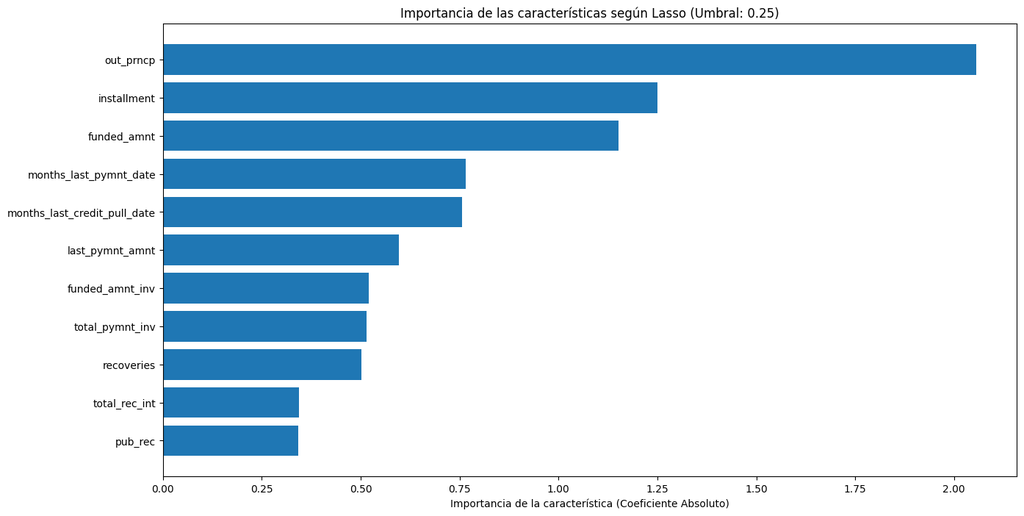

```python
# Modelo Lasso con validación cruzada para encontrar el mejor alpha
lasso = LassoCV(cv=5, random_state=42).fit(X_train, y_train)

# Selección de variables con SelectFromModel
model = SelectFromModel(lasso, prefit=True)

# Obtenemos las importancias de las características (coeficientes absolutos)
feature_importances = np.abs(lasso.coef_)

# Nombres de las variables
feature_names = X_train.columns.tolist()

# Definimos el umbral para seleccionar características
threshold = 0.25

# Filtramos características por encima del umbral
selected_indices = np.where(feature_importances > threshold)[0]
selected_feature_names = [feature_names[i] for i in selected_indices]
selected_importances = feature_importances[selected_indices]


# Ordenamos las características seleccionadas por importancia
sorted_indices = np.argsort(selected_importances)[::-1]
sorted_importances = selected_importances[sorted_indices]
sorted_variable_names = [selected_feature_names[i] for i in sorted_indices]

# Graficamos las importancias de las características seleccionadas
plt.figure(figsize=(15, 8))
plt.barh(sorted_variable_names, sorted_importances, align='center')
plt.xlabel('Importancia de la característica (Coeficiente Absoluto)')
plt.title(f'Importancia de las características según Lasso (Umbral: {threshold})')
plt.gca().invert_yaxis()  # Invertimos el eje Y para que la más importante esté arriba
plt.show()
```

Tal y cómo observamos, las variables elegidas por el modelo Lasso incluyendo a los procesos recuperatorios abiertos, son las mismas que sin incluirlos, lo cuál era bastante esperable puesto que el dichos procesos no representaban ni el 2% del total de la muestra.

```python
sorted_variable_names
```

```
['out_prncp',
 'installment',
 'funded_amnt',
 'months_last_pymnt_date',
 'months_last_credit_pull_date',
 'last_pymnt_amnt',
 'funded_amnt_inv',
 'total_pymnt_inv',
 'recoveries',
 'total_rec_int',
 'pub_rec']
```

```python
#Filtramos nuestros datasets con las variables más importantes seleccionadas por este modelo
X_train_lasso = X_train[sorted_variable_names]
X_test_lasso = X_test[sorted_variable_names]
df_explot_lasso = df_explot[sorted_variable_names]
```

Vamos a modelar con una Regresión Logística

```python
model_lr = LogisticRegression(
    penalty='l2', #(Ridge): reduce el tamaño de los coeficientes, pero sin hacerlos 0.
    C=0.01, #Controla la penalización de los coeficientes (inversa de la regularización).
    solver='lbfgs', #por defecto en L2, recomendado para datasets medianos a grandes.
    max_iter=100, # max_iter asegura convergencia
    class_weight = 'balanced',#'balanced': ajusta automáticamente los pesos de cada clase.
    random_state=42

)


model_lr.fit(X_train_lasso, y_train)
```

```
LogisticRegression(C=0.01, class_weight='balanced', random_state=42)
```

```python
# Hacer predicciones
y_train_pred_lr = model_lr.predict(X_train_lasso)
y_test_pred_lr = model_lr.predict(X_test_lasso)
```

```python
# Calcular probabilidades para ROC AUC
y_train_proba_lr = model_lr.predict_proba(X_train_lasso)[:, 1]
y_test_proba_lr = model_lr.predict_proba(X_test_lasso)[:, 1]
```

```
--- Entrenamiento ---
ROC AUC: 0.9968038533699142
Confusion Matrix:
[[19594    31]
 [ 1999 12100]]

Classification Report:
              precision    recall  f1-score   support

         0.0       0.91      1.00      0.95     19625
         1.0       1.00      0.86      0.92     14099

    accuracy                           0.94     33724
   macro avg       0.95      0.93      0.94     33724
weighted avg       0.95      0.94      0.94     33724


--- Prueba ---
ROC AUC: 0.9971576850462452
Confusion Matrix:
[[4898    8]
 [ 487 3038]]

Classification Report:
              precision    recall  f1-score   support

         0.0       0.91      1.00      0.95      4906
         1.0       1.00      0.86      0.92      3525

    accuracy                           0.94      8431
   macro avg       0.95      0.93      0.94      8431
weighted avg       0.95      0.94      0.94      8431
```

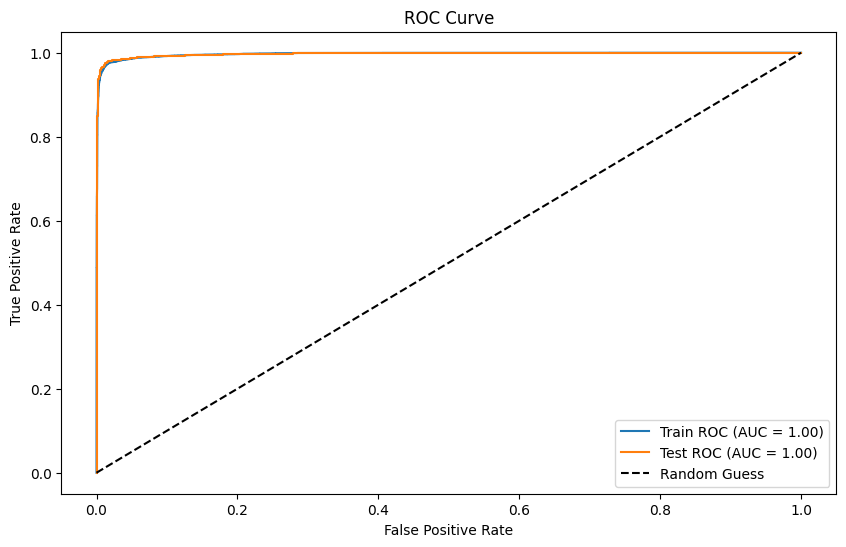

```python
evaluate_model(model_lr, X_train_lasso, y_train, X_test_lasso, y_test)
```

```python
#Guardamos el modelo
with open('clasificador_lr_LGD', 'wb') as f:
    pickle.dump(model_lr, f)
```

```python
#Cargar el modelo
with open('clasificador_lr_LGD', 'rb') as f:
    loaded_model = pickle.load(f)
```

```python
#Predecimos sobre el conjunto de explotación
y_pred_lr = loaded_model.predict(df_explot_lasso[X_train_lasso.columns])
```

Incluimos la predicción al conjunto de explotación con el resto de variables explicativas seleccionadas por el modelo Lasso.

```python
df_explot['LGD_LR'] = y_pred_lr
```

Observamos que la media de la LGD para el conjunto de explotación es muy superior a la LGD media del conjunto de construcción (85% vs 42%). Esto puede tener sentido debido a las variables elegidas por los modelos para predecir dependen en gran parte de los flujos estimados hasta ese momento, y en el caso de los procesos recuperatorios abiertos, dichos flujos están incompletos.

```python
X_train_lasso.columns
```

```
Index(['out_prncp', 'installment', 'funded_amnt', 'months_last_pymnt_date',
       'months_last_credit_pull_date', 'last_pymnt_amnt', 'funded_amnt_inv',
       'total_pymnt_inv', 'recoveries', 'total_rec_int', 'pub_rec'],
      dtype='object')
```

```python
df_explot['LGD_LR'].mean()
```

```
0.8500772797527048
```

```python
y_explot_proba_lr = model_lr.predict_proba(df_explot[X_train_lasso.columns])[:, 1]
```

```python
df_explot['probLR_LGD'] = y_explot_proba_lr
```

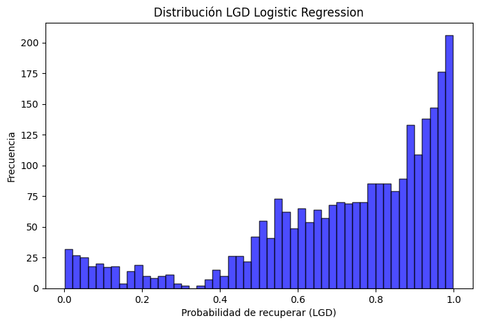

```python
plt.figure(figsize=(8,5))
plt.hist(df_explot['probLR_LGD'], bins=50, alpha=0.7, color='b', edgecolor='k')
plt.xlabel("Probabilidad de recuperar (LGD)")
plt.ylabel("Frecuencia")
plt.title("Distribución LGD Logistic Regression")
plt.show()
```

**RANDOM FOREST**

Reducción de la dimensionalidad con Random Forest

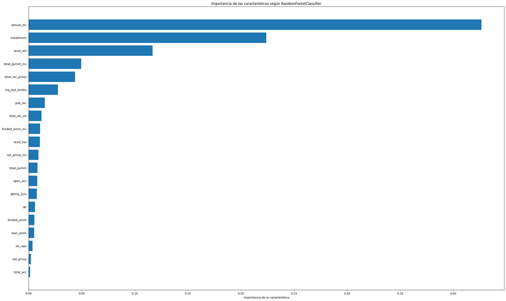

```python
random_forest = RandomForestClassifier (max_depth = 5).fit(X_train, y_train)

# Selección de las variables más importantes
model = SelectFromModel (random_forest, prefit=True) #prefit=True indica si el modelo fue entrenado antes de pasarlo a SelectFromModel, En este caso, el modelo no será reentrenado

# Obtenemos las importancias de las características
feature_importances = random_forest.feature_importances_

# Definir los nombres de las variables y un umbral
feature_names = X_train.columns.tolist()
threshold = 0.001

#filtrar las características por encima de ese umbral
selected_indices = np.where(feature_importances > threshold)[0]
selected_feature_names = [feature_names[i] for i in selected_indices]
selected_importances = feature_importances[selected_indices]


# Ordenamos las características por importancia
sorted_indices = np.argsort(selected_importances)[::-1]
sorted_importances = selected_importances[sorted_indices]
sorted_variable_names = [feature_names[i] for i in sorted_indices]

# Graficamos las importancias
plt.figure(figsize=(30, 18))
plt.barh(sorted_variable_names, sorted_importances, align='center')
plt.xlabel('Importancia de la característica')
plt.title('Importancia de las características según RandomForestClassifier')
plt.gca().invert_yaxis()  # Invertimos el eje Y para que la más importante esté arriba
plt.show()
```

Filtramos nuestros datasets con las variables más importantes seleccionadas por este modelo

```python
X_train_rf = X_train[sorted_variable_names]
X_test_rf = X_test[sorted_variable_names]
features_explot_rf = df_explot[sorted_variable_names]
```

Entrenar sobre el conjunto entrenamiento

```python
# Crear y entrenar el modelo de Random Forest

model_rf = RandomForestClassifier(
    n_estimators=100, #Número de árboles en el bosque.
    max_depth=5, #profundidad máxima de los árboles
    min_samples_split=5,  #Número mínimo de muestras requeridas para dividir un nodo (cuanto más alto menos sobreajuste)
    min_samples_leaf=3, #Número mínimo de muestras requeridas en una hoja (cuanto más alto menos sobreajuste)
    max_features='sqrt', #Número máximo de features consideradas en cada división.
    bootstrap=True,  #Si True, usa muestreo con reemplazo, lo que ayuda a la generalización
    random_state=32,
    n_jobs=-1,
    class_weight = "balanced"
)

model_rf.fit(X_train_rf, y_train)
```

```
RandomForestClassifier(class_weight='balanced', max_depth=5, min_samples_leaf=3,
                       min_samples_split=5, n_jobs=-1, random_state=32)
```

Predecir sobre el conjunto test

```python
# Hacer predicciones
y_train_pred_rf = model_rf.predict(X_train_rf)
y_test_pred_rf = model_rf.predict(X_test_rf)
```

```python
# Calcular probabilidades para ROC AUC
y_train_proba_rf = model_rf.predict_proba(X_train_rf)[:, 1]
y_test_proba_rf = model_rf.predict_proba(X_test_rf)[:, 1]
```

Evaluar sobre entrenamiento y test

```
--- Entrenamiento ---
ROC AUC: 0.9999983591915765
Confusion Matrix:
[[19597    28]
 [    0 14099]]

Classification Report:
              precision    recall  f1-score   support

         0.0       1.00      1.00      1.00     19625
         1.0       1.00      1.00      1.00     14099

    accuracy                           1.00     33724
   macro avg       1.00      1.00      1.00     33724
weighted avg       1.00      1.00      1.00     33724


--- Prueba ---
ROC AUC: 0.9997872051302067
Confusion Matrix:
[[4904    2]
 [   1 3524]]

Classification Report:
              precision    recall  f1-score   support

         0.0       1.00      1.00      1.00      4906
         1.0       1.00      1.00      1.00      3525

    accuracy                           1.00      8431
   macro avg       1.00      1.00      1.00      8431
weighted avg       1.00      1.00      1.00      8431
```

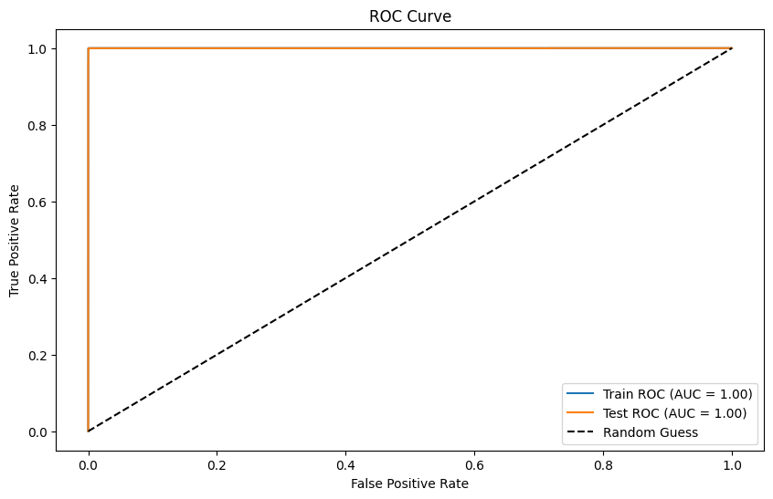

```python
evaluate_model(model_rf, X_train_rf, y_train, X_test_rf, y_test)
```

Guardar el modelo

```python
with open('clasificador_rf_LGD', 'wb') as f:
    pickle.dump(model_rf, f)
```

Cargar el modelo

```python
#Cargar el modelo
with open('clasificador_rf_LGD', 'rb') as f:
    loaded_model_rf = pickle.load(f)
```

Predecir sobre el conjunto de explotación

```python
y_pred_rf = loaded_model_rf.predict(df_explot[X_train_rf.columns])
```

Agregar LGD al conjunto de explotación

```python
df_explot['LGD_RF'] = y_pred_rf
```

LGD media del conjunto de explotación es incluso mayor que con una Regresión logística.

```python
df_explot['LGD'].mean()
```

```
0.8959317227266762
```

Graficar la distribución de la probabilidad de recuperar o no recuperar

```python
y_explot_proba_rf = model_rf.predict_proba(df_explot[X_train_rf.columns])[:, 1]
```

```python
df_explot['probRF_LGD'] = y_explot_proba_rf
```

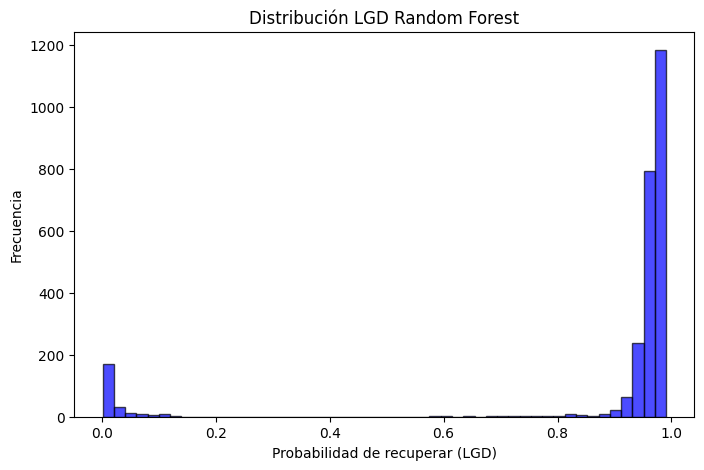

```python
plt.figure(figsize=(8,5))
plt.hist(df_explot['probRF_LGD'], bins=50, alpha=0.7, color='b', edgecolor='k')
plt.xlabel("Probabilidad de recuperar (LGD)")
plt.ylabel("Frecuencia")
plt.title("Distribución LGD Random Forest")
plt.show()
```

**XGBOOST**

Reducción de la dimensionalidad con XGBoost

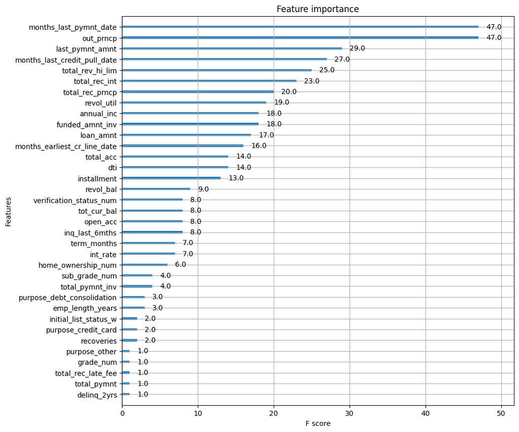

```python
xgb = XGBClassifier(max_depth=3, min_child_weight=5, gamma=0.3) #scale_pos_weight=scale_pos_weight)

xgb_model = xgb.fit(X_train, y_train)

# Crear la figura
fig, ax = plt.subplots(figsize=(10, 10))

# Mostrar la importancia de las características
plot_importance(xgb, ax=ax)

# Mostrar la gráfica
plt.show()
```

```python
# Extraer todas las variables ordenadas del gráfico
all_features = [text.get_text() for text in ax.get_yticklabels()]

# Extraer los valores del F score directamente desde el modelo
importance_dict = xgb.get_booster().get_score(importance_type='weight')

# Crear un DataFrame con las variables y su F score
importance_df = pd.DataFrame({
    'Feature': list(importance_dict.keys()),
    'F_score': list(importance_dict.values())
})

# Filtrar las variables con un F score por encima de un umbral
threshold = 10
important_features = importance_df[importance_df['F_score'] > threshold]

# Si quieres quedarte con solo los nombres de las variables:
important_features = important_features['Feature'].tolist()
important_features
```

```
['loan_amnt',
 'funded_amnt_inv',
 'installment',
 'annual_inc',
 'dti',
 'revol_util',
 'total_acc',
 'out_prncp',
 'total_rec_prncp',
 'total_rec_int',
 'last_pymnt_amnt',
 'total_rev_hi_lim',
 'months_earliest_cr_line_date',
 'months_last_pymnt_date',
 'months_last_credit_pull_date']
```

Filtramos nuestros datasets con las variables más importantes seleccionadas por este modelo

```python
X_train_xgb = X_train[important_features]
X_test_xgb = X_test[important_features]
features_explot_xgb = df_explot[important_features]
```

Entrenar sobre el conjunto entrenamiento

```python
model_xgb = XGBClassifier(
    max_depth=4, #Define la profundidad máxima de los árboles.
    min_child_weight=6, #Define la cantidad mínima de observaciones necesarias en un nodo hijo antes de dividirse.
    gamma=0.2, #Define la reducción mínima en la pérdida para hacer una nueva división en un nodo.
    reg_lambda=3, #Controla la penalización de los coeficientes grandes (similar a Ridge Regression).
    reg_alpha=2, #Induce sparsity (puede ayudar si hay muchas variables irrelevantes).
    colsample_bytree=0.7, #Porcentaje de variables usadas en cada árbol.
    learning_rate=0.05, #Reduce el impacto de cada árbol en la predicción final.
    n_estimators=500, #Número de árboles a entrenar.
    random_state=42,
    class_weight = "balanced",
    n_jobs=-1
)

model_xgb.fit(X_train_xgb, y_train)
```

```
XGBClassifier(base_score=None, booster=None, callbacks=None,
              class_weight='balanced', colsample_bylevel=None,
              colsample_bynode=None, colsample_bytree=0.7, device=None,
              early_stopping_rounds=None, enable_categorical=False,
              eval_metric=None, feature_types=None, gamma=0.2, grow_policy=None,
              importance_type=None, interaction_constraints=None,
              learning_rate=0.05, max_bin=None, max_cat_threshold=None,
              max_cat_to_onehot=None, max_delta_step=None, max_depth=4,
              max_leaves=None, min_child_weight=6, missing=nan,
              monotone_constraints=None, multi_strategy=None, n_estimators=500,
              n_jobs=-1, num_parallel_tree=None, ...)
```

Predecir sobre el conjunto test

```python
# Hacer predicciones
y_train_pred_xgb = model_xgb.predict(X_train_xgb)
y_test_pred_xgb = model_xgb.predict(X_test_xgb)
```

```python
# Calcular probabilidades para ROC AUC
y_train_proba_xgb = model_xgb.predict_proba(X_train_xgb)[:, 1]
y_test_proba_xgb = model_xgb.predict_proba(X_test_xgb)[:, 1]
```

Evaluar sobre entrenamiento y test

```
--- Entrenamiento ---
ROC AUC: 0.9999614482302807
Confusion Matrix:
[[19613    12]
 [   39 14060]]

Classification Report:
              precision    recall  f1-score   support

         0.0       1.00      1.00      1.00     19625
         1.0       1.00      1.00      1.00     14099

    accuracy                           1.00     33724
   macro avg       1.00      1.00      1.00     33724
weighted avg       1.00      1.00      1.00     33724


--- Prueba ---
ROC AUC: 0.9996140779997282
Confusion Matrix:
[[4905    1]
 [  15 3510]]

Classification Report:
              precision    recall  f1-score   support

         0.0       1.00      1.00      1.00      4906
         1.0       1.00      1.00      1.00      3525

    accuracy                           1.00      8431
   macro avg       1.00      1.00      1.00      8431
weighted avg       1.00      1.00      1.00      8431
```

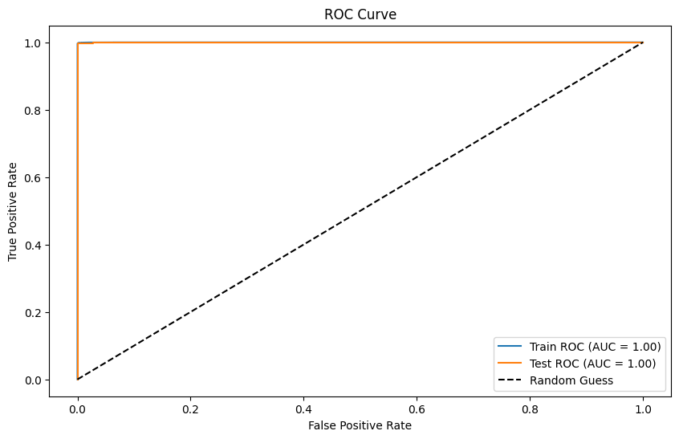

```python
evaluate_model(model_xgb, X_train_xgb, y_train, X_test_xgb, y_test)
```

Guardar el modelo

```python
with open('clasificador_xgb_LGD', 'wb') as f:
    pickle.dump(model_xgb, f)
```

Cargar el modelo

```python
with open('clasificador_xgb_LGD', 'rb') as f:
    loaded_model_xgb = pickle.load(f)
```

Predecir sobre el conjunto de explotación

```python
y_pred_xgb = loaded_model_xgb.predict(df_explot[X_train_xgb.columns])
```

Agregar LGD al conjunto de explotación

```python
df_explot['LGD_XGB'] = y_pred_xgb
```

LGD media del conjunto de explotación

```python
df_explot['LGD_XGB'].mean()
```

```
0.893353941267388
```

Graficar la distribución de probabilidad de recuperar o no recuperar

```python
y_explot_proba_xgb = model_xgb.predict_proba(df_explot[X_train_xgb.columns])[:, 1]
```

```python
df_explot['probXGB_LGD'] = y_explot_proba_xgb
```

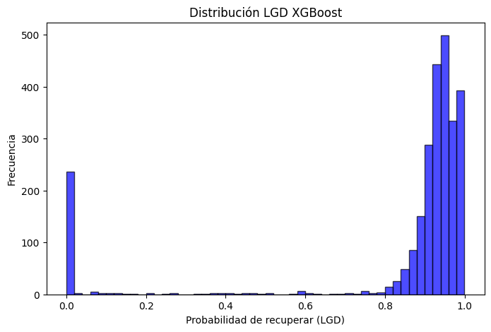

```python
plt.figure(figsize=(8,5))
plt.hist(df_explot['probXGB_LGD'], bins=50, alpha=0.7, color='b', edgecolor='k')
plt.xlabel("Probabilidad de recuperar (LGD)")
plt.ylabel("Frecuencia")
plt.title("Distribución LGD XGBoost")
plt.show()
```

**RED NEURONAL**

En el caso de una red neuronal no reducimos la dimensionalidad puesto que es preferible dejar que la propia red vaya seleccionando aquellas variables que más información aportan a las predicciones. Se puede analizar, **a posteriori** cuáles son aquellas variables mejores predictoras mediante diferentes técnicas (SHAP, ...)

```python
# Encontrar columnas comunes entre X_train y df_explot
common_columns = list(set(X_train.columns) & set(df_explot.columns))

# Filtrar ambos DataFrames para conservar solo las columnas en común
X_train_nn = X_train[common_columns]
X_test_nn = X_test[common_columns]
df_explot_nn = df_explot[common_columns]
```

Entrenar sobre el conjunto entrenamiento

```python
# Definir el coeficiente de regularización L2
lambda_l1 = 0.05

model = Sequential([
    Dense(128, activation='relu', input_shape=(X_train_nn.shape[1],), kernel_regularizer=l1(lambda_l1)),
    BatchNormalization(),
    Dropout(0.2),

    Dense(64, activation='relu', kernel_regularizer=l1(lambda_l1)),
    BatchNormalization(),
    Dropout(0.2),

    Dense(32, activation='relu', kernel_regularizer=l1(lambda_l1)),
    Dropout(0.1),

    Dense(1, activation='sigmoid')  # Salida binaria
])
```

```python
# Compilar el modelo
model.compile(
    optimizer=Adam(learning_rate=0.0001, decay=1e-6),  #una tasa de apredije menor a 0.0001, la red da unos saltos demasiado grandes, no llegando en ocasiones a coverger en resultados óptimos
    loss='binary_crossentropy',
    metrics=['AUC']
)
```

```python
# Callback para parada temprana
early_stopping = EarlyStopping(
    monitor='val_loss',  # Métrica a monitorear
    patience=3,          # Número de épocas sin mejora antes de detener el entrenamiento
    restore_best_weights=True  # Restaurar los pesos del mejor modelo
)
```

```python
# Callback para guardar el modelo después de cada época
checkpoint_callback = ModelCheckpoint(
    filepath='clasificador_nn_LGD.keras',  # Nombre del archivo donde se guarda
    monitor='val_loss',               # Métrica a monitorear
    save_best_only=True,              # Guardar solo el mejor modelo
    mode='min',                       # Minimizar la métrica (val_loss en este caso)
    verbose=1                         # Mostrar mensajes de guardado
)
```

```python
# Entrenar el modelo
history = model.fit(
    X_train_nn, y_train,
    validation_data=(X_test_nn, y_test),
    epochs=25,              # Número máximo de épocas (parada temprana detendrá antes si es necesario)
    batch_size=128,
    callbacks=[early_stopping, checkpoint_callback],  # Añadir los callbacks
    verbose=1
)
```

```
261/264 ━━━━━━━━━━━━━━━━━━━━ 0s 3ms/step - AUC: 0.4957 - loss: 79.0172
Epoch 1: val_loss improved from inf to 62.80462, saving model to clasificador_nn_LGD.keras
264/264 ━━━━━━━━━━━━━━━━━━━━ 4s 5ms/step - AUC: 0.4959 - loss: 78.9341 - val_AUC: 0.6080 - val_loss: 62.8046
253/264 ━━━━━━━━━━━━━━━━━━━━ 0s 3ms/step - AUC: 0.5506 - loss: 58.1843
Epoch 2: val_loss improved from 62.80462 to 44.30911, saving model to clasificador_nn_LGD.keras
264/264 ━━━━━━━━━━━━━━━━━━━━ 1s 4ms/step - AUC: 0.5514 - loss: 57.9720 - val_AUC: 0.6683 - val_loss: 44.3091
253/264 ━━━━━━━━━━━━━━━━━━━━ 0s 3ms/step - AUC: 0.6162 - loss: 40.4430
Epoch 3: val_loss improved from 44.30911 to 29.03518, saving model to clasificador_nn_LGD.keras
264/264 ━━━━━━━━━━━━━━━━━━━━ 1s 4ms/step - AUC: 0.6172 - loss: 40.2671 - val_AUC: 0.7372 - val_loss: 29.0352
249/264 ━━━━━━━━━━━━━━━━━━━━ 0s 3ms/step - AUC: 0.7132 - loss: 25.9936
Epoch 4: val_loss improved from 29.03518 to 17.08056, saving model to clasificador_nn_LGD.keras
264/264 ━━━━━━━━━━━━━━━━━━━━ 1s 4ms/step - AUC: 0.7155 - loss: 25.8086 - val_AUC: 0.8575 - val_loss: 17.0806
261/264 ━━━━━━━━━━━━━━━━━━━━ 0s 3ms/step - AUC: 0.8731 - loss: 14.6829
Epoch 5: val_loss improved from 17.08056 to 8.48924, saving model to clasificador_nn_LGD.keras
264/264 ━━━━━━━━━━━━━━━━━━━━ 1s 4ms/step - AUC: 0.8735 - loss: 14.6496 - val_AUC: 0.9713 - val_loss: 8.4892
252/264 ━━━━━━━━━━━━━━━━━━━━ 0s 3ms/step - AUC: 0.9721 - loss: 6.9543
Epoch 6: val_loss improved from 8.48924 to 3.28502, saving model to clasificador_nn_LGD.keras
264/264 ━━━━━━━━━━━━━━━━━━━━ 1s 4ms/step - AUC: 0.9726 - loss: 6.8880 - val_AUC: 0.9988 - val_loss: 3.2850
264/264 ━━━━━━━━━━━━━━━━━━━━ 0s 3ms/step - AUC: 0.9929 - loss: 2.6152
Epoch 7: val_loss improved from 3.28502 to 1.43125, saving model to clasificador_nn_LGD.keras
264/264 ━━━━━━━━━━━━━━━━━━━━ 1s 4ms/step - AUC: 0.9929 - loss: 2.6134 - val_AUC: 0.9992 - val_loss: 1.4312
252/264 ━━━━━━━━━━━━━━━━━━━━ 0s 3ms/step - AUC: 0.9936 - loss: 1.3069
Epoch 8: val_loss improved from 1.43125 to 0.89622, saving model to clasificador_nn_LGD.keras
264/264 ━━━━━━━━━━━━━━━━━━━━ 1s 4ms/step - AUC: 0.9935 - loss: 1.3001 - val_AUC: 0.9994 - val_loss: 0.8962
252/264 ━━━━━━━━━━━━━━━━━━━━ 0s 3ms/step - AUC: 0.9924 - loss: 0.8539
Epoch 9: val_loss improved from 0.89622 to 0.64821, saving model to clasificador_nn_LGD.keras
264/264 ━━━━━━━━━━━━━━━━━━━━ 1s 4ms/step - AUC: 0.9923 - loss: 0.8508 - val_AUC: 0.9995 - val_loss: 0.6482
253/264 ━━━━━━━━━━━━━━━━━━━━ 0s 3ms/step - AUC: 0.9914 - loss: 0.6523
Epoch 10: val_loss improved from 0.64821 to 0.55774, saving model to clasificador_nn_LGD.keras
264/264 ━━━━━━━━━━━━━━━━━━━━ 1s 4ms/step - AUC: 0.9914 - loss: 0.6514 - val_AUC: 0.9994 - val_loss: 0.5577
259/264 ━━━━━━━━━━━━━━━━━━━━ 0s 3ms/step - AUC: 0.9904 - loss: 0.5854
Epoch 11: val_loss improved from 0.55774 to 0.51318, saving model to clasificador_nn_LGD.keras
264/264 ━━━━━━━━━━━━━━━━━━━━ 1s 4ms/step - AUC: 0.9904 - loss: 0.5851 - val_AUC: 0.9994 - val_loss: 0.5132
264/264 ━━━━━━━━━━━━━━━━━━━━ 0s 3ms/step - AUC: 0.9925 - loss: 0.5392
Epoch 12: val_loss improved from 0.51318 to 0.47182, saving model to clasificador_nn_LGD.keras
264/264 ━━━━━━━━━━━━━━━━━━━━ 1s 4ms/step - AUC: 0.9925 - loss: 0.5391 - val_AUC: 0.9995 - val_loss: 0.4718
250/264 ━━━━━━━━━━━━━━━━━━━━ 0s 3ms/step - AUC: 0.9928 - loss: 0.5113
Epoch 13: val_loss improved from 0.47182 to 0.44245, saving model to clasificador_nn_LGD.keras
264/264 ━━━━━━━━━━━━━━━━━━━━ 1s 4ms/step - AUC: 0.9928 - loss: 0.5109 - val_AUC: 0.9995 - val_loss: 0.4425
253/264 ━━━━━━━━━━━━━━━━━━━━ 0s 3ms/step - AUC: 0.9928 - loss: 0.4839
```

[output cut: 20 more lines]

```
253/264 ━━━━━━━━━━━━━━━━━━━━ 0s 3ms/step - AUC: 0.9946 - loss: 0.3808
Epoch 21: val_loss improved from 0.32169 to 0.31277, saving model to clasificador_nn_LGD.keras
264/264 ━━━━━━━━━━━━━━━━━━━━ 1s 4ms/step - AUC: 0.9946 - loss: 0.3807 - val_AUC: 0.9996 - val_loss: 0.3128
252/264 ━━━━━━━━━━━━━━━━━━━━ 0s 3ms/step - AUC: 0.9943 - loss: 0.3720
Epoch 22: val_loss improved from 0.31277 to 0.30867, saving model to clasificador_nn_LGD.keras
264/264 ━━━━━━━━━━━━━━━━━━━━ 1s 4ms/step - AUC: 0.9944 - loss: 0.3719 - val_AUC: 0.9995 - val_loss: 0.3087
262/264 ━━━━━━━━━━━━━━━━━━━━ 0s 3ms/step - AUC: 0.9955 - loss: 0.3618
Epoch 23: val_loss improved from 0.30867 to 0.29383, saving model to clasificador_nn_LGD.keras
264/264 ━━━━━━━━━━━━━━━━━━━━ 1s 4ms/step - AUC: 0.9955 - loss: 0.3618 - val_AUC: 0.9995 - val_loss: 0.2938
252/264 ━━━━━━━━━━━━━━━━━━━━ 0s 3ms/step - AUC: 0.9957 - loss: 0.3550
Epoch 24: val_loss improved from 0.29383 to 0.28990, saving model to clasificador_nn_LGD.keras
264/264 ━━━━━━━━━━━━━━━━━━━━ 1s 4ms/step - AUC: 0.9957 - loss: 0.3549 - val_AUC: 0.9995 - val_loss: 0.2899
253/264 ━━━━━━━━━━━━━━━━━━━━ 0s 3ms/step - AUC: 0.9947 - loss: 0.3501
Epoch 25: val_loss improved from 0.28990 to 0.28351, saving model to clasificador_nn_LGD.keras
264/264 ━━━━━━━━━━━━━━━━━━━━ 1s 4ms/step - AUC: 0.9947 - loss: 0.3500 - val_AUC: 0.9995 - val_loss: 0.2835
```

```python
# Extraer los datos del entrenamiento
history_dict = history.history
```

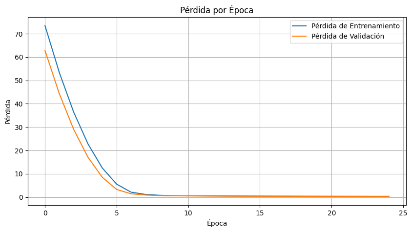

```python
# Gráficos de pérdida (loss)
plt.figure(figsize=(10, 5))
plt.plot(history_dict['loss'], label='Pérdida de Entrenamiento')
plt.plot(history_dict['val_loss'], label='Pérdida de Validación')
plt.title('Pérdida por Época')
plt.xlabel('Época')
plt.ylabel('Pérdida')
plt.legend()
plt.grid()
plt.show()
```

```python
# Gráficos de ROC AUC, si está disponible
if 'mse' in history_dict:
    plt.figure(figsize=(10, 5))
    plt.plot(history_dict['mse'], label='MSE de Entrenamiento')
    plt.plot(history_dict['val_mse'], label='MSE de Validación')
    plt.title('MSE por Época')
    plt.xlabel('Época')
    plt.ylabel('MSE')
    plt.legend()
    plt.grid()
    plt.show()
```

Predecir y evaluar sobre el conjunto test.

```python
# Evaluación con .evaluate
loss, roc_auc = model.evaluate(X_test_nn, y_test)

# Predicciones manuales
y_pred_proba = model.predict(X_test_nn)
roc_auc_manual = roc_auc_score(y_test, y_pred_proba)

print(f"ROC AUC (.evaluate): {roc_auc:.4f}")
print(f"ROC AUC (manual): {roc_auc_manual:.4f}")
```

```
264/264 ━━━━━━━━━━━━━━━━━━━━ 0s 1ms/step - AUC: 0.9992 - loss: 0.2863
264/264 ━━━━━━━━━━━━━━━━━━━━ 0s 1ms/step
ROC AUC (.evaluate): 0.9995
ROC AUC (manual): 0.9995
```

Ya hemos agregado el código en la estructura de la red para que el modelo grabe automaticamente el mejor score.

Cargar el modelo

```python
modelo_cargado_nn = load_model("clasificador_nn_LGD.keras")
```

```python
X_train_nn.columns
```

```
Index(['total_rec_late_fee', 'purpose_major_purchase', 'tot_cur_bal',
       'filtered_emp_title_driver', 'filtered_emp_title_technology',
       'total_pymnt_inv', 'funded_amnt_inv', 'total_rec_int',
       'total_rec_prncp', 'purpose_credit_card', 'total_rev_hi_lim',
       'filtered_emp_title_finance', 'last_pymnt_amnt', 'revol_bal',
       'filtered_emp_title_senior', 'installment', 'recoveries',
       'out_prncp_inv', 'addr_state_grouped', 'filtered_emp_title_operations',
       'months_last_pymnt_date', 'term_months', 'annual_inc',
       'emp_length_years', 'months_last_credit_pull_date',
       'purpose_debt_consolidation', 'inq_last_6mths', 'grade_num',
       'verification_status_num', 'total_acc', 'filtered_emp_title_security',
       'purpose_medical', 'initial_list_status_w', 'delinq_2yrs',
       'collections_12_mths_ex_med', 'dti', 'out_prncp',
       'collection_recovery_fee', 'int_rate', 'sub_grade_num', 'purpose_house',
       'funded_amnt', 'tot_coll_amt', 'pub_rec', 'acc_now_delinq',
       'revol_util', 'open_acc', 'purpose_small_business',
       'filtered_emp_title_specialist', 'purpose_other', 'zip_code_grouped',
       'filtered_emp_title_healthcare', 'purpose_moving', 'loan_amnt',
       'total_pymnt', 'months_earliest_cr_line_date', 'purpose_vacation',
       'filtered_emp_title_management', 'purpose_home_improvement',
       'filtered_emp_title_other', 'home_ownership_num'],
      dtype='object')
```

```python
df_explot[X_train_nn.columns]
```

|  | total_rec_late_fee | purpose_major_purchase | tot_cur_bal | filtered_emp_title_driver | filtered_emp_title_technology | total_pymnt_inv | funded_amnt_inv | total_rec_int | total_rec_prncp | purpose_credit_card | ... | filtered_emp_title_healthcare | purpose_moving | loan_amnt | total_pymnt | months_earliest_cr_line_date | purpose_vacation | filtered_emp_title_management | purpose_home_improvement | filtered_emp_title_other | home_ownership_num |
| --- | --- | --- | --- | --- | --- | --- | --- | --- | --- | --- | --- | --- | --- | --- | --- | --- | --- | --- | --- | --- | --- |
| 0 | 0.0 | False | 0.013819 | False | False | 0.024405 | 0.235294 | 0.017009 | 0.020780 | True | ... | False | False | 0.235294 | 0.024405 | 0.636598 | False | False | False | True | 1.0 |
| 1 | 0.0 | False | 0.225268 | False | False | 0.116223 | 0.852941 | 0.198130 | 0.066611 | False | ... | True | False | 0.852941 | 0.116223 | 0.689003 | False | False | False | False | 1.0 |
| 2 | 0.0 | False | 0.030219 | False | False | 0.044568 | 0.205882 | 0.040806 | 0.035255 | False | ... | False | False | 0.205882 | 0.044568 | 0.719931 | False | False | False | True | 0.0 |
| 3 | 0.0 | False | 0.011575 | False | False | 0.050232 | 0.252941 | 0.026472 | 0.045126 | True | ... | False | False | 0.252941 | 0.050232 | 0.711340 | False | True | False | False | 1.0 |
| 4 | 0.0 | False | 0.254741 | False | False | 0.163701 | 0.676471 | 0.126181 | 0.136040 | False | ... | False | False | 0.676471 | 0.163701 | 0.622852 | False | True | False | False | 1.0 |
| ... | ... | ... | ... | ... | ... | ... | ... | ... | ... | ... | ... | ... | ... | ... | ... | ... | ... | ... | ... | ... | ... |
| 355 | 0.0 | False | 0.148586 | False | False | 0.061447 | 0.069118 | 0.071381 | 0.049325 | False | ... | False | False | 0.069118 | 0.061447 | 0.720430 | NaN | False | False | False | 1.0 |
| 356 | 0.0 | False | 0.038458 | False | False | 0.042137 | 0.411765 | 0.063533 | 0.030308 | True | ... | False | False | 0.411765 | 0.042137 | 0.730287 | NaN | False | False | True | 0.0 |
| 357 | 0.0 | False | 0.031268 | False | False | 0.674918 | 0.397059 | 0.023964 | 0.725000 | False | ... | False | False | 0.397059 | 0.674918 | 0.629032 | NaN | False | False | False | 0.0 |
| 358 | 0.0 | False | 0.214704 | False | False | 0.254221 | 0.411765 | 0.171129 | 0.234007 | False | ... | False | False | 0.411765 | 0.254221 | 0.761649 | NaN | True | False | False | 1.0 |
| 359 | 0.0 | False | 0.373682 | False | False | 0.412708 | 0.676471 | 0.316639 | 0.370532 | True | ... | False | False | 0.676471 | 0.412708 | 0.788530 | NaN | False | False | False | 0.5 |

2588 rows × 61 columns

Predecir sobre el conjunto de explotación

```python
y_pred_proba_nn = modelo_cargado_nn.predict(df_explot[X_train_nn.columns])
```

```
81/81 ━━━━━━━━━━━━━━━━━━━━ 0s 2ms/step
```

```python
# Predecir probabilidades y convertirlas a etiquetas para calcular la media de la LGD
y_pred_nn = (y_pred_proba_nn > 0.5).astype(int)
```

Agregar LGD al conjunto de explotación

```python
df_explot['LGD_NN'] = y_pred_nn
```

LGD media del conjunto de explotación

```python
df_explot['LGD_NN'].mean()
```

```
0.7809119010819165
```

Observamos cómo la LGD media de conjunto de explotación es la más baja de todos los modelos, lo cuál podría ser positivo, ya que nos acercamos más a la LGD media del conjunto de construcción (aunque aún se encuentra muy lejos, 78% vs 42%). Pero muy probablemente esta circunstacncia se debe a que la estructura de la red no está bien ajustada y la red neuronal predice peor en explotación que los otros 3 modelos. No vamos a ajustar la red neuronal, porque hemos visto cómo intentar estimar la LGD de un conjunto de procesos recuperatarios abiertos empleando técnicas de ML/AI no funciona, puesto que los modelos se basan en los flujos conocidos hasta esa fecha y en base a dichos flujos los modelos llevan a cabo sus predicciones. El problema es que dichos flujos aún no están completos y los modelos podrían estar infraestimando las recuperaciones, por lo que debemos llevar cabo otras técnicas.

```python
df_explot['probNN_LGD'] = y_pred_proba_nn
```

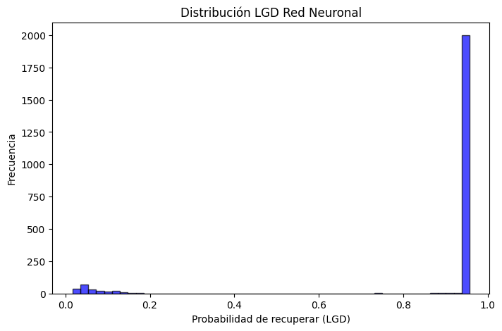

```python
plt.figure(figsize=(8,5))
plt.hist(df_explot['probNN_LGD'], bins=50, alpha=0.7, color='b', edgecolor='k')
plt.xlabel("Probabilidad de recuperar (LGD)")
plt.ylabel("Frecuencia")
plt.title("Distribución LGD Red Neuronal")
plt.show()
```

### 8. CONCLUSIÓN

Ya hemos comprobado cómo, debido a que no contamos con mucho detalle en relación a los flujos recuperatorios, costes, fecha de entrada en default, exposición en el momento del default, ... los modelos están limitados a predecir la LGD de los procesos recuperatorios abiertos basándose en los importes brutos de los flujos recuperatorios y en alguna otra variables externa. Pero en este dataset no se dispone de demasiado detalle para que los modelos puedan predecir de manera satisfactoria la LGD de la cartera de explotación. De ahí que se obtengan LGDs tan elevadas en los procesos abiertos.  
Por ello, vamos a llevar a cabo un segmentado del conjunto de construcción de los procesos recuperatorios cerrados y vamos a asignar a los procesos recuperatorios abiertos, la LGD media que corresponda a la media de su segmento.

Dicho segmentado deberá llevarse a cabo por aquellas variables consideradas más importantes por los 3 modelos vistos anteriormente mediante los cuales hemos reducido la dimensionalidad (Lasso, Random Forest y XGBoost)

```python
list(set(X_train_lasso.columns) & set(X_train_rf.columns) & set(X_train_xgb.columns))
```

```
['funded_amnt_inv', 'total_rec_int', 'out_prncp', 'installment']
```

```python
X_train_rf.columns
```

```
Index(['annual_inc', 'installment', 'revol_util', 'total_pymnt_inv',
       'total_rec_prncp', 'inq_last_6mths', 'pub_rec', 'total_rec_int',
       'funded_amnt_inv', 'revol_bal', 'out_prncp_inv', 'total_pymnt',
       'open_acc', 'delinq_2yrs', 'dti', 'funded_amnt', 'loan_amnt',
       'int_rate', 'out_prncp', 'total_acc'],
      dtype='object')
```